# learning analysis, new subjects

Ben Smith

2022-12-19

We’ve noticed an accumbens signal that has a particularly pronounced CS-FS difference among late trials.

That led us to ask: is it correlated with reaction time; specifically,

1. is accumbens BOLD CS-FS contrast at tone+5 s (which reacts negatively) negatively related to longer reaction times in subsequent trials, and
2. is accumbens bold CS-FS contrast at tone+9 (which reacts positively) positively related to longer reaction times in subsequent trials?

We are really mostly interested in FS so at the trial level we’d do

1. is accumbens BOLD FS contrast at tone+5 s (which reacts positively) positively related to longer reaction times in subsequent trials, and
2. is accumbens bold FS contrast at tone+9 (which reacts negatively) negatively related to longer reaction times in subsequent trials?

# Prep

```r
library(tidyverse)
Sys.setenv(R_CONFIG_ACTIVE = Sys.info()["nodename"])
print(Sys.info()["nodename"])
```

```
##                        nodename
## "Benjamins-MacBook-Pro-3.local"
```

```r
dropbbox_dir <- config::get("dev_analysis_data_dir")
```

```r
time_points <- readr::read_csv(paste0(dropbbox_dir,"/SST_roi_by_time_point.csv"))
```

```
## ──────────────────────────────────────────────────────── Delimiter: "," chr
## (3): subid, go_no_go_condition_label, condition dbl (17): ...1, tr, offset,
## CueFollowing(CS>FS)striatal_cluster_combined_202...
```

So how do we design this experiment; what are we correlating over, exactly? Some designs are:

1. Across subject, so:
1. apply the script I have created on late trials to get average measurements every 10 s–maybe the last half or third of the task, not just the last few, but do this at a per subject level
2. take the MAXIMUM accumbens activity at the 1-9 s range across trials for each subject (to get the peak), and the MINIMUM accumbens activity at the 4-12 s range (to get the trough)
3. correlate across subject average reaction times, or post-pre change in reaction times
2. Within subject, so:
1. get peak and trough accumbens signal for each FS trial in the last third of the task. Perhaps use the difference between the peak and trough as your measure. Though we’re really now kind of getting a crude HRF…the advantage of this measure is we aren’t bound to a particular shape of it, which is probably useful.
2. get (i) reaction time and (ii) post-pre difference for subsequent go trial
3. correlate the difference of peak and trough gathered in (a) with the two measures in (b). Summarize in two ways: i. get average correlations within-subject, then average across subjects as a crude multi-level model to test across subject ii. apply a true multi-level model

We’ll want to re-use existing pre-post data.

So–this will yield quite different data to the data we used previously!

```r
roi_cols <- colnames(time_points)[grepl("harvardoxford",colnames(time_points))]
time_points$tr_roi_mean <- rowMeans(time_points[,roi_cols])
time_points<-
  time_points %>% group_by(subid,wave) %>%
  mutate(run_mean_across_rois = mean(tr_roi_mean, na.rm = TRUE))

#now mean-center the ROIs
time_points_c<-time_points
for (roi_col in roi_cols){
  time_points_c[,roi_col]<-time_points_c[,roi_col]-time_points_c$run_mean_across_rois
}

#roi_cols <- colnames(time_points_c)[grepl("harvardoxford",colnames(time_points_c))]
#roi_cols_all <- colnames(time_points_c)#[grepl("((?<=harvardoxford-.{0,3}cortical_prob_)(.*))|(CueFollowing\\(CS\\>FS\\).*)",colnames(time_points_c),perl=TRUE)]
roi_detect_pattern<-"((?<=harvardoxford-.{0,3}cortical_prob_)(.*))|(CueFollowing\\(CS\\>FS\\).*)"

roi_cols_vec <- colnames(time_points_c) %>% stringr::str_detect(pattern = roi_detect_pattern)
new_roi_cols <- colnames(time_points_c) %>% stringr::str_extract_all(pattern = roi_detect_pattern) %>% unlist
unique(new_roi_cols)
```

```
##  [1] "CueFollowing(CS>FS)striatal_cluster_combined_20230512"
##  [2] "CueFollowing(CS>FS)striatal_cluster_combined_20221207"
##  [3] "CueFollowing(CS>FS)striatal_cluster_combined"
##  [4] "Frontal Orbital Cortex"
##  [5] "Cingulate Gyrus, anterior division"
##  [6] "Left Caudate"
##  [7] "Right Accumbens"
##  [8] "Right Putamen"
##  [9] "Left Putamen"
## [10] "Right Caudate"
## [11] "Left Accumbens"
```

```r
colnames(time_points_c)[roi_cols_vec] <- new_roi_cols
```

We need to group by subject, wave, and trial, select just the FailedStop trials, and just the high trial numbers, then get the min and max accumbens activity. We could even do a long transform across the ROIs, then also group by ROI and get the min and max for ROIs

So let’s first long transform the ROIs

```r
tpc_long<-time_points_c %>% pivot_longer(cols=all_of(new_roi_cols),names_to="ROI",values_to="value")
```

Now do the grouping and summarizing.

```r
trial_summary_data <- tpc_long %>%
  #filter(condition=="FailedStop") %>%
  group_by(subid,wave,trial_n,ROI, condition) %>%
  summarise(
    peak=max(value[offset>=4.0 & offset <=11.0],na.rm = TRUE),
    trough = min(value[offset>=4.0 & offset <=11.0],na.rm = TRUE),
    peak_time = offset[offset>=4.0 & offset <=11.0][value[offset>=4.0 & offset <=11.0]==max(value[offset>=4.0 & offset <=11.0],na.rm = TRUE)],
    trough_time = offset[offset>=4.0 & offset <=11.0][value[offset>=4.0 & offset <=11.0]==min(value[offset>=4.0 & offset <=11.0],na.rm = TRUE)],
    med_post_trial = median(value[offset>=4.0 & offset <=10.0],na.rm = TRUE)


  )
```

```
## 'condition'. You can override using the `.groups` argument.
```

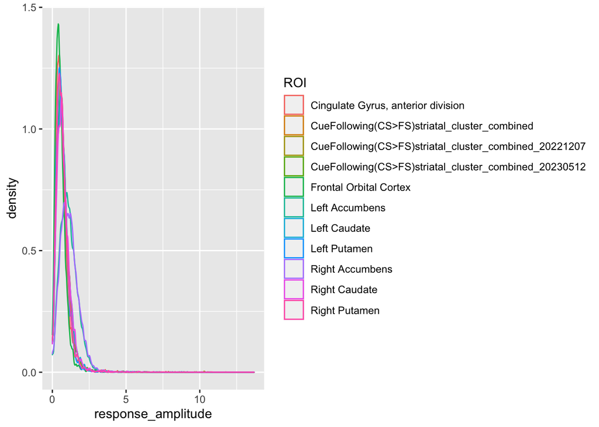

```r
trial_summary_data$response_amplitude <-trial_summary_data$peak-trial_summary_data$trough

ggplot(trial_summary_data %>% filter(condition=="FailedStop"),aes(response_amplitude,group=ROI,color=ROI))+geom_density(adjust=0.5)
```

OK. So now, let’s try to merge in that with post-pre RTs. Where do we get those from?

## get the SST Post-pre data

```r
source(paste0(config::get("ben_dev_data_analysis"),"SST_processing.R"))

dropbox_file_dir = config::get("dev_analysis_data_dir")
sst_all_data_filepath <- paste0(dropbox_file_dir,"sst_behavioral_data_all.csv")

sst_all_data_raw <- readr::read_csv(sst_all_data_filepath)
sst_all_data<-clean_sst_data(sst_all_data_raw)
sst_all_data <- get_expected_tone_time(sst_all_data)

sst_all_data<-calculate_response_latency(sst_all_data)
sst_all_data<-calculate_rpe(sst_all_data)

sst_all_data<-get_more_sst_stats(sst_all_data)
```

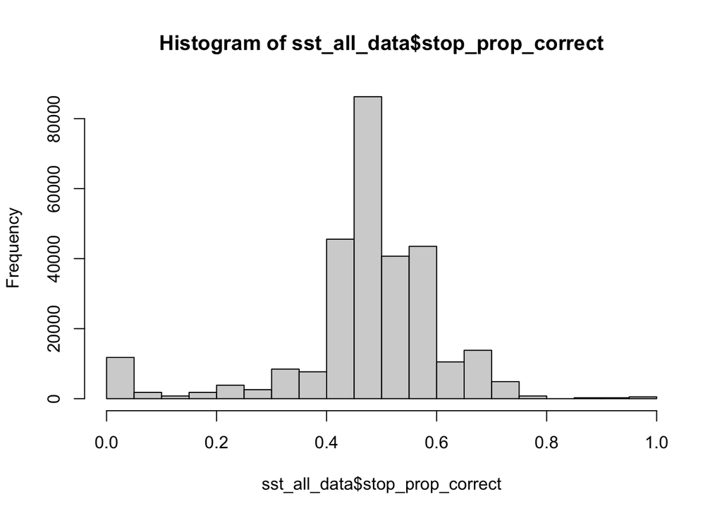

```r
#remove subjects with two many incorrect trials--theyre' probably not paying attention
hist(sst_all_data$stop_prop_correct)
```

```r
sst_all_data <- sst_all_data %>% filter(stop_prop_correct>0.2 & stop_prop_correct<0.8)


# sst_all_data %>% select(
#   subid, waveid, runid, reaction_time_clean, SSD_recorded,condition, last_tone_delay, trials_since_last_SSD,last_correct_go)# %>%
#   #View()
```

```r
readr::write_csv(sst_all_data,file=paste0(dropbox_file_dir,"sst_behavioral_data_all_with_analysis.csv"))
```

```r
post_pre_rt_data <- sst_all_data%>%
  filter(condition!="Cue") #%>%
  #select(trial_n,reaction_time,subid,waveid,runid,condition,post_pre_rt_change)
```

## Prepare neural data

```r
trial_summary_data$ROI_delateralized <-  trial_summary_data$ROI %>% str_replace_all("(Left|Right)\\s","")


trial_summary_data_delat <- trial_summary_data %>%
  #filter(ROI %in% c("Left Accumbens","Right Accumbens")) %>%
  group_by(subid,wave,trial_n, ROI_delateralized,condition) %>%
  summarize(peak=mean(peak),
            trough=mean(trough),
            peak_time=mean(peak_time),
            trough_time=mean(trough_time),
            response_amplitude=mean(response_amplitude),
            med_post_trial=mean(med_post_trial)
            )
```

```
## 'ROI_delateralized'. You can override using the `.groups` argument.
```

## Merge the datasets

```r
trial_summary_data_delat_pp <- merge(trial_summary_data_delat,post_pre_rt_data,by.x = c("subid","wave","trial_n","condition"),by.y=c("subid","waveid","trial_n","condition"),all.x = TRUE)

trial_summary_data_delat_pp$trial_n_c<-128-trial_summary_data_delat_pp$trial_n
```

# Preparing regressors

```r
trial_neural_behav_data_not_na<-trial_summary_data_delat_pp[
  rowSums(is.na(trial_summary_data_delat_pp[,c("response_amplitude","post_pre_rt_change")]))==0 & #no NA values in correlation and
    is.finite(trial_summary_data_delat_pp$response_amplitude) & is.finite(trial_summary_data_delat_pp$post_pre_rt_change) #no infinite values
    ,]

trial_neural_behav_data_not_na$trial_n_c<-128-trial_neural_behav_data_not_na$trial_n


trial_neural_behav_roi <- trial_neural_behav_data_not_na %>% filter(ROI_delateralized=="CueFollowing(CS>FS)striatal_cluster_combined")

trial_neural_behav_roi$condition<-(
  factor(trial_neural_behav_roi$condition,
            levels=c("CorrectGo","CorrectStop","FailedGo","FailedStop"),
            ordered=FALSE))


trial_neural_behav_roi$trial_n_s<-scale(trial_neural_behav_roi$trial_n_c)
```

```r
trial_neural_behav_roi$peak_z<-scale(trial_neural_behav_roi$peak)
trial_neural_behav_roi$post_pre_rt_change_z<-scale(trial_neural_behav_roi$post_pre_rt_change)
trial_neural_behav_roi$P_stop_trial_change_z<-scale(trial_neural_behav_roi$P_stop_trial_change)
trial_neural_behav_roi$trial_n_z<-scale(trial_neural_behav_roi$trial_n)
trial_neural_behav_roi$med_post_trial_z<-scale(trial_neural_behav_roi$med_post_trial)
```

# Basic Striatal cluster mixed effects models

# All trial types, with P_Stop

I think if you’re going to do P_stop

- P_stop_trial seems mostly irrelevant and P_stop_trial_post is a more relevant measure; P_stop_trial_change is more relevant still.
- measuring P_stop_trial rather than P_stop_trial_change doesn’t make much sense, but
- If you’re only measuring FS, neither P_stop_trial_post nor P_stop_trial_change are necessarily going to measure what you think because the data is censored to just FS trials, which are *always* going to move in a particular direction
- so while measuring `P_stop_trial`, it’s best to do a model with all kinds of trials

## all conditions, without condition

```r
model_full_effects <- lme4::lmer(
   med_post_trial_z ~ trial_n_s + P_stop_trial_change+ post_pre_rt_change + (1 +post_pre_rt_change  + P_stop_trial_change  | subid),
  trial_neural_behav_roi %>% filter(trial_n>50)
  )
```

```
## boundary (singular) fit: see help('isSingular')
```

```r
summary(model_full_effects)
```

```
## Linear mixed model fit by REML ['lmerMod']
## Formula:
## med_post_trial_z ~ trial_n_s + P_stop_trial_change + post_pre_rt_change +
##     (1 + post_pre_rt_change + P_stop_trial_change | subid)
##    Data: trial_neural_behav_roi %>% filter(trial_n > 50)
##
## REML criterion at convergence: 95735
##
## Scaled residuals:
##      Min       1Q   Median       3Q      Max
## -14.9755  -0.6000   0.0366   0.6261   4.0783
##
## Random effects:
##  Groups   Name                Variance  Std.Dev.  Corr
##  subid    (Intercept)         2.374e-03 0.0487215
##           post_pre_rt_change  4.148e-09 0.0000644 -1.00
##           P_stop_trial_change 5.078e+01 7.1260046 -0.67  0.67
##  Residual                     9.622e-01 0.9809404
## Number of obs: 34139, groups:  subid, 271
##
## Fixed effects:
##                      Estimate Std. Error t value
## (Intercept)          0.035464   0.006653   5.331
## trial_n_s            0.048080   0.006693   7.184
## P_stop_trial_change -1.702351   0.884034  -1.926
## post_pre_rt_change  -0.101733   0.037029  -2.747
##
## Correlation of Fixed Effects:
##             (Intr) trl_n_ P_st__
## trial_n_s    0.379
## P_stp_trl_c -0.047  0.057
## pst_pr_rt_c  0.015  0.003 -0.119
## optimizer (nloptwrap) convergence code: 0 (OK)
## boundary (singular) fit: see help('isSingular')
```

## stop conditions, without condition

```r
model_full_effects <- lme4::lmer(
   med_post_trial_z ~ trial_n_s + P_stop_trial_change+ post_pre_rt_change + (1 +post_pre_rt_change  + P_stop_trial_change  | subid),
  trial_neural_behav_roi %>% filter(trial_n>50 & condition %in% c("CorrectStop","FailedStop"))
  )
```

```
## boundary (singular) fit: see help('isSingular')
```

```r
summary(model_full_effects)
```

```
## Linear mixed model fit by REML ['lmerMod']
## Formula:
## med_post_trial_z ~ trial_n_s + P_stop_trial_change + post_pre_rt_change +
##     (1 + post_pre_rt_change + P_stop_trial_change | subid)
##    Data: trial_neural_behav_roi %>% filter(trial_n > 50 & condition %in%
##     c("CorrectStop", "FailedStop"))
##
## REML criterion at convergence: 19459.3
##
## Scaled residuals:
##     Min      1Q  Median      3Q     Max
## -9.6830 -0.6052  0.0205  0.6228  3.8813
##
## Random effects:
##  Groups   Name                Variance Std.Dev. Corr
##  subid    (Intercept)          0.00000 0.0000
##           post_pre_rt_change   0.05044 0.2246     NaN
##           P_stop_trial_change 61.54196 7.8449     NaN -0.30
##  Residual                      1.03958 1.0196
## Number of obs: 6739, groups:  subid, 271
##
## Fixed effects:
##                     Estimate Std. Error t value
## (Intercept)         -0.46557    0.07762  -5.998
## trial_n_s           -0.17894    0.03881  -4.611
## P_stop_trial_change 33.78660    5.35923   6.304
## post_pre_rt_change  -0.44406    0.08431  -5.267
##
## Correlation of Fixed Effects:
##             (Intr) trl_n_ P_st__
## trial_n_s    0.927
## P_stp_trl_c -0.979 -0.908
## pst_pr_rt_c -0.018  0.029 -0.028
## optimizer (nloptwrap) convergence code: 0 (OK)
## boundary (singular) fit: see help('isSingular')
```

## stop conditions, with condition

```r
model_full_effects <- lme4::lmer(
   med_post_trial_z ~ trial_n_s+ condition + P_stop_trial_change+ post_pre_rt_change + (1 +post_pre_rt_change  + P_stop_trial_change  | subid),
  trial_neural_behav_roi %>% filter(trial_n>50 & condition %in% c("CorrectStop","FailedStop"))
  )
```

```
## boundary (singular) fit: see help('isSingular')
```

```r
summary(model_full_effects)
```

```
## Linear mixed model fit by REML ['lmerMod']
## Formula: med_post_trial_z ~ trial_n_s + condition + P_stop_trial_change +
##     post_pre_rt_change + (1 + post_pre_rt_change + P_stop_trial_change |
##     subid)
##    Data: trial_neural_behav_roi %>% filter(trial_n > 50 & condition %in%
##     c("CorrectStop", "FailedStop"))
##
## REML criterion at convergence: 19175.2
##
## Scaled residuals:
##      Min       1Q   Median       3Q      Max
## -10.1216  -0.5907   0.0303   0.6086   4.0506
##
## Random effects:
##  Groups   Name                Variance Std.Dev. Corr
##  subid    (Intercept)          0.00000 0.0000
##           post_pre_rt_change   0.05978 0.2445     NaN
##           P_stop_trial_change 50.98112 7.1401     NaN -0.27
##  Residual                      0.99678 0.9984
## Number of obs: 6739, groups:  subid, 271
##
## Fixed effects:
##                     Estimate Std. Error t value
## (Intercept)         -0.33834    0.07635  -4.431
## trial_n_s           -0.20398    0.03802  -5.364
## conditionFailedStop -0.42969    0.02497 -17.207
## P_stop_trial_change 37.24173    5.24663   7.098
## post_pre_rt_change  -0.24719    0.08361  -2.956
##
## Correlation of Fixed Effects:
##             (Intr) trl_n_ cndtFS P_st__
## trial_n_s    0.919
## cndtnFldStp -0.097  0.038
## P_stp_trl_c -0.971 -0.909 -0.038
## pst_pr_rt_c -0.004  0.023 -0.137 -0.022
## optimizer (nloptwrap) convergence code: 0 (OK)
## boundary (singular) fit: see help('isSingular')
```

```r
model_no_rt<- lme4::lmer(
   med_post_trial_z ~ trial_n_s+ condition + P_stop_trial_change + (1 +post_pre_rt_change  + P_stop_trial_change  | subid),
  trial_neural_behav_roi %>% filter(trial_n>50 & condition %in% c("CorrectStop","FailedStop"))
  )
```

```
## boundary (singular) fit: see help('isSingular')
```

```r
anova(model_full_effects,model_no_rt)
```

```
## refitting model(s) with ML (instead of REML)
```

```
## Data: trial_neural_behav_roi %>% filter(trial_n > 50 & condition %in%  ...
## Models:
## model_no_rt: med_post_trial_z ~ trial_n_s + condition + P_stop_trial_change + (1 + post_pre_rt_change + P_stop_trial_change | subid)
## model_full_effects: med_post_trial_z ~ trial_n_s + condition + P_stop_trial_change + post_pre_rt_change + (1 + post_pre_rt_change + P_stop_trial_change | subid)
##                    npar   AIC   BIC  logLik deviance  Chisq Df Pr(>Chisq)
## model_no_rt          11 19189 19264 -9583.5    19167
## model_full_effects   12 19182 19264 -9579.2    19158 8.5413  1   0.003472 **
## ---
## Signif. codes:  0 '***' 0.001 '**' 0.01 '*' 0.05 '.' 0.1 ' ' 1
```

```r
model_no_p_stop<- lme4::lmer(
   med_post_trial_z ~ trial_n_s+ condition + post_pre_rt_change + (1 +post_pre_rt_change  + P_stop_trial_change  | subid),
  trial_neural_behav_roi %>% filter(trial_n>50 & condition %in% c("CorrectStop","FailedStop"))
  )

anova(model_full_effects,model_no_p_stop)
```

```
## refitting model(s) with ML (instead of REML)
```

```
## Data: trial_neural_behav_roi %>% filter(trial_n > 50 & condition %in%  ...
## Models:
## model_no_p_stop: med_post_trial_z ~ trial_n_s + condition + post_pre_rt_change + (1 + post_pre_rt_change + P_stop_trial_change | subid)
## model_full_effects: med_post_trial_z ~ trial_n_s + condition + P_stop_trial_change + post_pre_rt_change + (1 + post_pre_rt_change + P_stop_trial_change | subid)
##                    npar   AIC   BIC  logLik deviance  Chisq Df Pr(>Chisq)
## model_no_p_stop      11 19217 19292 -9597.5    19195
## model_full_effects   12 19182 19264 -9579.2    19158 36.689  1  1.385e-09 ***
## ---
## Signif. codes:  0 '***' 0.001 '**' 0.01 '*' 0.05 '.' 0.1 ' ' 1
```

### condition RT interaction

```r
model_full_effects <- lme4::lmer(
   med_post_trial_z ~ trial_n_s+ condition + P_stop_trial_change+ post_pre_rt_change + post_pre_rt_change:(condition=="FailedStop")+ (1 +post_pre_rt_change + post_pre_rt_change:(condition=="FailedStop") + P_stop_trial_change  | subid),
  trial_neural_behav_roi %>% filter(trial_n>50 & condition %in% c("CorrectStop","FailedStop"))
  )
```

```
## boundary (singular) fit: see help('isSingular')
```

```r
summary(model_full_effects)
```

```
## Linear mixed model fit by REML ['lmerMod']
## Formula: med_post_trial_z ~ trial_n_s + condition + P_stop_trial_change +
##     post_pre_rt_change + post_pre_rt_change:(condition == "FailedStop") +
##     (1 + post_pre_rt_change + post_pre_rt_change:(condition ==
##         "FailedStop") + P_stop_trial_change | subid)
##    Data: trial_neural_behav_roi %>% filter(trial_n > 50 & condition %in%
##     c("CorrectStop", "FailedStop"))
##
## REML criterion at convergence: 19175.7
##
## Scaled residuals:
##      Min       1Q   Median       3Q      Max
## -10.1406  -0.5895   0.0310   0.6107   4.0594
##
## Random effects:
##  Groups   Name                                             Variance Std.Dev.
##  subid    (Intercept)                                       0.00000 0.0000
##           post_pre_rt_change                                0.04175 0.2043
##           P_stop_trial_change                              49.34653 7.0247
##           post_pre_rt_change:condition == "FailedStop"TRUE  0.17792 0.4218
##  Residual                                                   0.99552 0.9978
##  Corr
##
##    NaN
##    NaN -0.84
##    NaN -0.18  0.52
##
## Number of obs: 6739, groups:  subid, 271
##
## Fixed effects:
##                                                  Estimate Std. Error t value
## (Intercept)                                      -0.33662    0.07635  -4.409
## trial_n_s                                        -0.20357    0.03803  -5.353
## conditionFailedStop                              -0.43468    0.02603 -16.699
## P_stop_trial_change                              37.20009    5.24704   7.090
## post_pre_rt_change                               -0.29219    0.11325  -2.580
## post_pre_rt_change:condition == "FailedStop"TRUE  0.09704    0.16718   0.580
##
## Correlation of Fixed Effects:
##             (Intr) trl_n_ cndtFS P_st__ pst___
## trial_n_s    0.919
## cndtnFldStp -0.093  0.041
## P_stp_trl_c -0.970 -0.909 -0.043
## pst_pr_rt_c -0.005  0.026  0.096 -0.035
## p___:=="FS"  0.002 -0.014 -0.278  0.028 -0.671
## optimizer (nloptwrap) convergence code: 0 (OK)
## boundary (singular) fit: see help('isSingular')
```

That interaction isn’t significant–let’s take it away

```r
model_full_effects <- lme4::lmer(
   med_post_trial_z ~ trial_n_s+ condition + +P_stop_trial_change+ post_pre_rt_change +  (1 +post_pre_rt_change +  P_stop_trial_change   | subid),
  trial_neural_behav_roi %>% filter(trial_n>50 & condition %in% c("CorrectStop","FailedStop"))
  )
```

```
## boundary (singular) fit: see help('isSingular')
```

```r
summary(model_full_effects)
```

```
## Linear mixed model fit by REML ['lmerMod']
## Formula: med_post_trial_z ~ trial_n_s + condition + +P_stop_trial_change +
##     post_pre_rt_change + (1 + post_pre_rt_change + P_stop_trial_change |
##     subid)
##    Data: trial_neural_behav_roi %>% filter(trial_n > 50 & condition %in%
##     c("CorrectStop", "FailedStop"))
##
## REML criterion at convergence: 19175.2
##
## Scaled residuals:
##      Min       1Q   Median       3Q      Max
## -10.1216  -0.5907   0.0303   0.6086   4.0506
##
## Random effects:
##  Groups   Name                Variance Std.Dev. Corr
##  subid    (Intercept)          0.00000 0.0000
##           post_pre_rt_change   0.05978 0.2445     NaN
##           P_stop_trial_change 50.98112 7.1401     NaN -0.27
##  Residual                      0.99678 0.9984
## Number of obs: 6739, groups:  subid, 271
##
## Fixed effects:
##                     Estimate Std. Error t value
## (Intercept)         -0.33834    0.07635  -4.431
## trial_n_s           -0.20398    0.03802  -5.364
## conditionFailedStop -0.42969    0.02497 -17.207
## P_stop_trial_change 37.24173    5.24663   7.098
## post_pre_rt_change  -0.24719    0.08361  -2.956
##
## Correlation of Fixed Effects:
##             (Intr) trl_n_ cndtFS P_st__
## trial_n_s    0.919
## cndtnFldStp -0.097  0.038
## P_stp_trl_c -0.971 -0.909 -0.038
## pst_pr_rt_c -0.004  0.023 -0.137 -0.022
## optimizer (nloptwrap) convergence code: 0 (OK)
## boundary (singular) fit: see help('isSingular')
```

## z-scored

### with condition interactions

```r
model_P_stop_trial_w_change <- lme4::lmer(
   med_post_trial_z ~ trial_n_z +condition + post_pre_rt_change_z + P_stop_trial_change_z + P_stop_trial_change_z:(condition=="FailedStop") +(1+ post_pre_rt_change_z + P_stop_trial_change_z + P_stop_trial_change_z:(condition=="FailedStop") | subid),
  trial_neural_behav_roi %>% filter(trial_n>50 & condition %in% c("CorrectStop","FailedStop"))
  )
```

```
## boundary (singular) fit: see help('isSingular')
```

```r
summary(model_P_stop_trial_w_change)
```

```
## Linear mixed model fit by REML ['lmerMod']
## Formula: med_post_trial_z ~ trial_n_z + condition + post_pre_rt_change_z +
##     P_stop_trial_change_z + P_stop_trial_change_z:(condition ==
##     "FailedStop") + (1 + post_pre_rt_change_z + P_stop_trial_change_z +
##     P_stop_trial_change_z:(condition == "FailedStop") | subid)
##    Data: trial_neural_behav_roi %>% filter(trial_n > 50 & condition %in%
##     c("CorrectStop", "FailedStop"))
##
## REML criterion at convergence: 19155.5
##
## Scaled residuals:
##      Min       1Q   Median       3Q      Max
## -10.0588  -0.5846   0.0279   0.6069   4.0320
##
## Random effects:
##  Groups   Name                                                Variance Std.Dev.
##  subid    (Intercept)                                         0.000000 0.0000
##           post_pre_rt_change_z                                0.001183 0.0344
##           P_stop_trial_change_z                               0.177307 0.4211
##           P_stop_trial_change_z:condition == "FailedStop"TRUE 0.703225 0.8386
##  Residual                                                     0.979104 0.9895
##  Corr
##
##    NaN
##    NaN  0.43
##    NaN -0.77 -0.75
##
## Number of obs: 6739, groups:  subid, 271
##
## Fixed effects:
##                                                     Estimate Std. Error t value
## (Intercept)                                         -0.42707    0.08468  -5.044
## trial_n_z                                            0.20131    0.03800   5.297
## conditionFailedStop                                 -0.27019    0.05964  -4.531
## post_pre_rt_change_z                                -0.03833    0.01225  -3.128
## P_stop_trial_change_z                                1.81290    0.24388   7.434
## P_stop_trial_change_z:condition == "FailedStop"TRUE -0.53775    0.19290  -2.788
##
## Correlation of Fixed Effects:
##             (Intr) trl_n_ cndtFS ps____ P_s___
## trial_n_z   -0.882
## cndtnFldStp -0.329  0.019
## pst_pr_rt__ -0.003 -0.022 -0.077
## P_stp_trl__ -0.972  0.853  0.328 -0.014
## P____:=="FS  0.310 -0.037 -0.874 -0.019 -0.383
## optimizer (nloptwrap) convergence code: 0 (OK)
## boundary (singular) fit: see help('isSingular')
```

```r
#ignoring post_pre_rt_change_z
model_P_stop_trial_w_change_no_rt <- lme4::lmer(
   med_post_trial_z ~ trial_n_z +condition +  P_stop_trial_change_z + P_stop_trial_change_z:(condition=="FailedStop") +(1+ post_pre_rt_change_z + P_stop_trial_change_z + P_stop_trial_change_z:(condition=="FailedStop") | subid),
  trial_neural_behav_roi %>% filter(trial_n>50 & condition %in% c("CorrectStop","FailedStop"))
  )
```

```
## boundary (singular) fit: see help('isSingular')
```

```r
summary(model_P_stop_trial_w_change_no_rt)
```

```
## Linear mixed model fit by REML ['lmerMod']
## Formula: med_post_trial_z ~ trial_n_z + condition + P_stop_trial_change_z +
##     P_stop_trial_change_z:(condition == "FailedStop") + (1 +
##     post_pre_rt_change_z + P_stop_trial_change_z + P_stop_trial_change_z:(condition ==
##     "FailedStop") | subid)
##    Data: trial_neural_behav_roi %>% filter(trial_n > 50 & condition %in%
##     c("CorrectStop", "FailedStop"))
##
## REML criterion at convergence: 19158
##
## Scaled residuals:
##      Min       1Q   Median       3Q      Max
## -10.0759  -0.5908   0.0270   0.6124   4.0566
##
## Random effects:
##  Groups   Name                                                Variance Std.Dev.
##  subid    (Intercept)                                         0.000000 0.00000
##           post_pre_rt_change_z                                0.002604 0.05103
##           P_stop_trial_change_z                               0.181509 0.42604
##           P_stop_trial_change_z:condition == "FailedStop"TRUE 0.693289 0.83264
##  Residual                                                     0.979261 0.98958
##  Corr
##
##    NaN
##    NaN  0.20
##    NaN -0.55 -0.74
##
## Number of obs: 6739, groups:  subid, 271
##
## Fixed effects:
##                                                     Estimate Std. Error t value
## (Intercept)                                         -0.42873    0.08473  -5.060
## trial_n_z                                            0.19915    0.03802   5.238
## conditionFailedStop                                 -0.28409    0.05950  -4.774
## P_stop_trial_change_z                                1.80238    0.24404   7.385
## P_stop_trial_change_z:condition == "FailedStop"TRUE -0.55016    0.19283  -2.853
##
## Correlation of Fixed Effects:
##             (Intr) trl_n_ cndtFS P_s___
## trial_n_z   -0.882
## cndtnFldStp -0.330  0.017
## P_stp_trl__ -0.972  0.853  0.328
## P____:=="FS  0.310 -0.037 -0.878 -0.384
## optimizer (nloptwrap) convergence code: 0 (OK)
## boundary (singular) fit: see help('isSingular')
```

```r
anova(model_P_stop_trial_w_change,model_P_stop_trial_w_change_no_rt)
```

```
## refitting model(s) with ML (instead of REML)
```

```
## Data: trial_neural_behav_roi %>% filter(trial_n > 50 & condition %in%  ...
## Models:
## model_P_stop_trial_w_change_no_rt: med_post_trial_z ~ trial_n_z + condition + P_stop_trial_change_z + P_stop_trial_change_z:(condition == "FailedStop") + (1 + post_pre_rt_change_z + P_stop_trial_change_z + P_stop_trial_change_z:(condition == "FailedStop") | subid)
## model_P_stop_trial_w_change: med_post_trial_z ~ trial_n_z + condition + post_pre_rt_change_z + P_stop_trial_change_z + P_stop_trial_change_z:(condition == "FailedStop") + (1 + post_pre_rt_change_z + P_stop_trial_change_z + P_stop_trial_change_z:(condition == "FailedStop") | subid)
##                                   npar   AIC   BIC  logLik deviance  Chisq Df
## model_P_stop_trial_w_change_no_rt   16 19169 19278 -9568.4    19137
## model_P_stop_trial_w_change         17 19161 19277 -9563.7    19127 9.5348  1
##                                   Pr(>Chisq)
## model_P_stop_trial_w_change_no_rt
## model_P_stop_trial_w_change         0.002016 **
## ---
## Signif. codes:  0 '***' 0.001 '**' 0.01 '*' 0.05 '.' 0.1 ' ' 1
```

```r
#ignoring P_stop_trial_change_z
model_P_stop_trial_w_change_no_p_stop_d <- lme4::lmer(
   med_post_trial_z ~ trial_n_z +condition +  post_pre_rt_change_z +(1+ post_pre_rt_change_z + P_stop_trial_change_z + P_stop_trial_change_z:(condition=="FailedStop") | subid),
  trial_neural_behav_roi %>% filter(trial_n>50 & condition %in% c("CorrectStop","FailedStop"))
  )
```

```
## boundary (singular) fit: see help('isSingular')
```

```r
summary(model_P_stop_trial_w_change_no_p_stop_d)
```

```
## Linear mixed model fit by REML ['lmerMod']
## Formula: med_post_trial_z ~ trial_n_z + condition + post_pre_rt_change_z +
##     (1 + post_pre_rt_change_z + P_stop_trial_change_z + P_stop_trial_change_z:(condition ==
##         "FailedStop") | subid)
##    Data: trial_neural_behav_roi %>% filter(trial_n > 50 & condition %in%
##     c("CorrectStop", "FailedStop"))
##
## REML criterion at convergence: 19207.8
##
## Scaled residuals:
##      Min       1Q   Median       3Q      Max
## -10.0430  -0.5802   0.0232   0.6139   4.1548
##
## Random effects:
##  Groups   Name                                                Variance
##  subid    (Intercept)                                         0.0000000
##           post_pre_rt_change_z                                0.0008748
##           P_stop_trial_change_z                               0.1942471
##           P_stop_trial_change_z:condition == "FailedStop"TRUE 0.7705133
##  Residual                                                     0.9860725
##  Std.Dev. Corr
##  0.00000
##  0.02958    NaN
##  0.44073    NaN  0.59
##  0.87779    NaN -0.96 -0.76
##  0.99301
## Number of obs: 6739, groups:  subid, 271
##
## Fixed effects:
##                      Estimate Std. Error t value
## (Intercept)           0.18444    0.01925   9.580
## trial_n_z            -0.04023    0.01592  -2.526
## conditionFailedStop  -0.41125    0.02942 -13.977
## post_pre_rt_change_z -0.03722    0.01223  -3.042
##
## Correlation of Fixed Effects:
##             (Intr) trl_n_ cndtFS
## trial_n_z   -0.339
## cndtnFldStp -0.596 -0.032
## pst_pr_rt__ -0.079 -0.005 -0.200
## optimizer (nloptwrap) convergence code: 0 (OK)
## boundary (singular) fit: see help('isSingular')
```

```r
anova(model_P_stop_trial_w_change, model_P_stop_trial_w_change_no_p_stop_d)
```

```
## refitting model(s) with ML (instead of REML)
```

```
## Data: trial_neural_behav_roi %>% filter(trial_n > 50 & condition %in%  ...
## Models:
## model_P_stop_trial_w_change_no_p_stop_d: med_post_trial_z ~ trial_n_z + condition + post_pre_rt_change_z + (1 + post_pre_rt_change_z + P_stop_trial_change_z + P_stop_trial_change_z:(condition == "FailedStop") | subid)
## model_P_stop_trial_w_change: med_post_trial_z ~ trial_n_z + condition + post_pre_rt_change_z + P_stop_trial_change_z + P_stop_trial_change_z:(condition == "FailedStop") + (1 + post_pre_rt_change_z + P_stop_trial_change_z + P_stop_trial_change_z:(condition == "FailedStop") | subid)
##                                         npar   AIC   BIC  logLik deviance
## model_P_stop_trial_w_change_no_p_stop_d   15 19212 19314 -9591.2    19182
## model_P_stop_trial_w_change               17 19161 19277 -9563.7    19127
##                                          Chisq Df Pr(>Chisq)
## model_P_stop_trial_w_change_no_p_stop_d
## model_P_stop_trial_w_change             54.966  2   1.16e-12 ***
## ---
## Signif. codes:  0 '***' 0.001 '**' 0.01 '*' 0.05 '.' 0.1 ' ' 1
```

### no interactions

```r
model_P_stop_trial_w_change <- lme4::lmer(
   med_post_trial_z ~ trial_n_z +condition + post_pre_rt_change_z + P_stop_trial_change_z +(1+ post_pre_rt_change_z + P_stop_trial_change_z  | subid),
  trial_neural_behav_roi %>% filter(trial_n>50 & condition %in% c("CorrectStop","FailedStop"))
  )
```

```
## boundary (singular) fit: see help('isSingular')
```

```r
summary(model_P_stop_trial_w_change)
```

```
## Linear mixed model fit by REML ['lmerMod']
## Formula: med_post_trial_z ~ trial_n_z + condition + post_pre_rt_change_z +
##     P_stop_trial_change_z + (1 + post_pre_rt_change_z + P_stop_trial_change_z |
##     subid)
##    Data: trial_neural_behav_roi %>% filter(trial_n > 50 & condition %in%
##     c("CorrectStop", "FailedStop"))
##
## REML criterion at convergence: 19176.7
##
## Scaled residuals:
##      Min       1Q   Median       3Q      Max
## -10.1043  -0.5911   0.0311   0.6096   4.0209
##
## Random effects:
##  Groups   Name                  Variance  Std.Dev. Corr
##  subid    (Intercept)           0.0409449 0.20235
##           post_pre_rt_change_z  0.0001507 0.01228   1.00
##           P_stop_trial_change_z 0.6807841 0.82510  -0.99 -0.99
##  Residual                       0.9916807 0.99583
## Number of obs: 6739, groups:  subid, 271
##
## Fixed effects:
##                       Estimate Std. Error t value
## (Intercept)           -0.35465    0.08132  -4.361
## trial_n_z              0.20187    0.03806   5.304
## conditionFailedStop   -0.43191    0.02492 -17.330
## post_pre_rt_change_z  -0.03615    0.01205  -3.000
## P_stop_trial_change_z  1.56581    0.23104   6.777
##
## Correlation of Fixed Effects:
##             (Intr) trl_n_ cndtFS ps____
## trial_n_z   -0.908
## cndtnFldStp -0.090 -0.037
## pst_pr_rt__  0.002 -0.024 -0.139
## P_stp_trl__ -0.975  0.889 -0.036 -0.033
## optimizer (nloptwrap) convergence code: 0 (OK)
## boundary (singular) fit: see help('isSingular')
```

```r
model_P_stop_trial_w_change_no_rt <- lme4::lmer(
   med_post_trial_z ~ trial_n_z +condition + P_stop_trial_change_z +(1+ post_pre_rt_change_z + P_stop_trial_change_z  | subid),
  trial_neural_behav_roi %>% filter(trial_n>50 & condition %in% c("CorrectStop","FailedStop"))
  )
summary(model_P_stop_trial_w_change_no_rt)
```

```
## Linear mixed model fit by REML ['lmerMod']
## Formula: med_post_trial_z ~ trial_n_z + condition + P_stop_trial_change_z +
##     (1 + post_pre_rt_change_z + P_stop_trial_change_z | subid)
##    Data: trial_neural_behav_roi %>% filter(trial_n > 50 & condition %in%
##     c("CorrectStop", "FailedStop"))
##
## REML criterion at convergence: 19178.2
##
## Scaled residuals:
##      Min       1Q   Median       3Q      Max
## -10.0932  -0.5910   0.0308   0.6156   4.0515
##
## Random effects:
##  Groups   Name                  Variance Std.Dev. Corr
##  subid    (Intercept)           0.038713 0.19676
##           post_pre_rt_change_z  0.002319 0.04816   0.22
##           P_stop_trial_change_z 0.673115 0.82044  -0.99 -0.27
##  Residual                       0.991190 0.99559
## Number of obs: 6739, groups:  subid, 271
##
## Fixed effects:
##                       Estimate Std. Error t value
## (Intercept)           -0.35612    0.08132  -4.379
## trial_n_z              0.19985    0.03807   5.249
## conditionFailedStop   -0.44162    0.02471 -17.872
## P_stop_trial_change_z  1.54803    0.23099   6.702
##
## Correlation of Fixed Effects:
##             (Intr) trl_n_ cndtFS
## trial_n_z   -0.909
## cndtnFldStp -0.091 -0.041
## P_stp_trl__ -0.975  0.889 -0.040
```

```r
anova(model_P_stop_trial_w_change,model_P_stop_trial_w_change_no_rt)
```

```
## refitting model(s) with ML (instead of REML)
```

```
## Data: trial_neural_behav_roi %>% filter(trial_n > 50 & condition %in%  ...
## Models:
## model_P_stop_trial_w_change_no_rt: med_post_trial_z ~ trial_n_z + condition + P_stop_trial_change_z + (1 + post_pre_rt_change_z + P_stop_trial_change_z | subid)
## model_P_stop_trial_w_change: med_post_trial_z ~ trial_n_z + condition + post_pre_rt_change_z + P_stop_trial_change_z + (1 + post_pre_rt_change_z + P_stop_trial_change_z | subid)
##                                   npar   AIC   BIC  logLik deviance  Chisq Df
## model_P_stop_trial_w_change_no_rt   11 19180 19255 -9579.2    19158
## model_P_stop_trial_w_change         12 19174 19256 -9574.9    19150 8.5682  1
##                                   Pr(>Chisq)
## model_P_stop_trial_w_change_no_rt
## model_P_stop_trial_w_change         0.003421 **
## ---
## Signif. codes:  0 '***' 0.001 '**' 0.01 '*' 0.05 '.' 0.1 ' ' 1
```

```r
model_P_stop_trial_w_change_no_p_stop_d <- lme4::lmer(
   med_post_trial_z ~ trial_n_z +condition +  post_pre_rt_change_z +(1+ post_pre_rt_change_z + P_stop_trial_change_z | subid),
  trial_neural_behav_roi %>% filter(trial_n>50 & condition %in% c("CorrectStop","FailedStop"))
  )
summary(model_P_stop_trial_w_change_no_p_stop_d)
```

```
## Linear mixed model fit by REML ['lmerMod']
## Formula: med_post_trial_z ~ trial_n_z + condition + post_pre_rt_change_z +
##     (1 + post_pre_rt_change_z + P_stop_trial_change_z | subid)
##    Data: trial_neural_behav_roi %>% filter(trial_n > 50 & condition %in%
##     c("CorrectStop", "FailedStop"))
##
## REML criterion at convergence: 19220.7
##
## Scaled residuals:
##      Min       1Q   Median       3Q      Max
## -10.0397  -0.5883   0.0325   0.6163   4.0876
##
## Random effects:
##  Groups   Name                  Variance  Std.Dev. Corr
##  subid    (Intercept)           0.0564408 0.23757
##           post_pre_rt_change_z  0.0003812 0.01952   0.77
##           P_stop_trial_change_z 0.8879563 0.94231  -0.99 -0.69
##  Residual                       0.9957596 0.99788
## Number of obs: 6739, groups:  subid, 271
##
## Fixed effects:
##                      Estimate Std. Error t value
## (Intercept)           0.18064    0.01831   9.865
## trial_n_z            -0.02321    0.01799  -1.290
## conditionFailedStop  -0.42679    0.02498 -17.087
## post_pre_rt_change_z -0.03332    0.01212  -2.750
##
## Correlation of Fixed Effects:
##             (Intr) trl_n_ cndtFS
## trial_n_z   -0.422
## cndtnFldStp -0.552 -0.013
## pst_pr_rt__ -0.130  0.017 -0.140
## optimizer (nloptwrap) convergence code: 0 (OK)
## unable to evaluate scaled gradient
## Model failed to converge: degenerate  Hessian with 1 negative eigenvalues
```

```r
anova(model_P_stop_trial_w_change, model_P_stop_trial_w_change_no_p_stop_d)
```

```
## refitting model(s) with ML (instead of REML)
```

```
## Data: trial_neural_behav_roi %>% filter(trial_n > 50 & condition %in%  ...
## Models:
## model_P_stop_trial_w_change_no_p_stop_d: med_post_trial_z ~ trial_n_z + condition + post_pre_rt_change_z + (1 + post_pre_rt_change_z + P_stop_trial_change_z | subid)
## model_P_stop_trial_w_change: med_post_trial_z ~ trial_n_z + condition + post_pre_rt_change_z + P_stop_trial_change_z + (1 + post_pre_rt_change_z + P_stop_trial_change_z | subid)
##                                         npar   AIC   BIC  logLik deviance
## model_P_stop_trial_w_change_no_p_stop_d   11 19217 19292 -9597.5    19195
## model_P_stop_trial_w_change               12 19174 19256 -9574.9    19150
##                                          Chisq Df Pr(>Chisq)
## model_P_stop_trial_w_change_no_p_stop_d
## model_P_stop_trial_w_change             45.312  1   1.68e-11 ***
## ---
## Signif. codes:  0 '***' 0.001 '**' 0.01 '*' 0.05 '.' 0.1 ' ' 1
```

### no interactions, all trials

```r
model_P_stop_trial_w_change <- lme4::lmer(
   med_post_trial_z ~ trial_n_z +condition + post_pre_rt_change_z + P_stop_trial_change_z +(1+ post_pre_rt_change_z + P_stop_trial_change_z  | subid),
  trial_neural_behav_roi %>% filter(trial_n & condition %in% c("CorrectStop","FailedStop"))
  )
```

```
## boundary (singular) fit: see help('isSingular')
```

```r
summary(model_P_stop_trial_w_change)
```

```
## Linear mixed model fit by REML ['lmerMod']
## Formula: med_post_trial_z ~ trial_n_z + condition + post_pre_rt_change_z +
##     P_stop_trial_change_z + (1 + post_pre_rt_change_z + P_stop_trial_change_z |
##     subid)
##    Data:
## trial_neural_behav_roi %>% filter(trial_n & condition %in% c("CorrectStop",
##     "FailedStop"))
##
## REML criterion at convergence: 25716.8
##
## Scaled residuals:
##      Min       1Q   Median       3Q      Max
## -10.1364  -0.5977   0.0257   0.6234   4.1365
##
## Random effects:
##  Groups   Name                  Variance Std.Dev. Corr
##  subid    (Intercept)           0.006109 0.07816
##           post_pre_rt_change_z  0.001150 0.03391  -0.77
##           P_stop_trial_change_z 0.005058 0.07112  -0.99  0.87
##  Residual                       1.007494 1.00374
## Number of obs: 8998, groups:  subid, 271
##
## Fixed effects:
##                       Estimate Std. Error t value
## (Intercept)            0.24195    0.01683  14.372
## trial_n_z             -0.06661    0.01257  -5.300
## conditionFailedStop   -0.44388    0.02187 -20.292
## post_pre_rt_change_z  -0.02076    0.01074  -1.933
## P_stop_trial_change_z -0.09786    0.01042  -9.389
##
## Correlation of Fixed Effects:
##             (Intr) trl_n_ cndtFS ps____
## trial_n_z   -0.224
## cndtnFldStp -0.562  0.080
## pst_pr_rt__ -0.168 -0.009 -0.151
## P_stp_trl__ -0.438  0.460 -0.100  0.190
## optimizer (nloptwrap) convergence code: 0 (OK)
## boundary (singular) fit: see help('isSingular')
```

```r
model_P_stop_trial_w_change_no_rt <- lme4::lmer(
   med_post_trial_z ~ trial_n_z +condition + P_stop_trial_change_z +(1+ post_pre_rt_change_z + P_stop_trial_change_z  | subid),
  trial_neural_behav_roi %>% filter(trial_n & condition %in% c("CorrectStop","FailedStop"))
  )
```

```
## boundary (singular) fit: see help('isSingular')
```

```r
summary(model_P_stop_trial_w_change_no_rt)
```

```
## Linear mixed model fit by REML ['lmerMod']
## Formula: med_post_trial_z ~ trial_n_z + condition + P_stop_trial_change_z +
##     (1 + post_pre_rt_change_z + P_stop_trial_change_z | subid)
##    Data:
## trial_neural_behav_roi %>% filter(trial_n & condition %in% c("CorrectStop",
##     "FailedStop"))
##
## REML criterion at convergence: 25713.3
##
## Scaled residuals:
##      Min       1Q   Median       3Q      Max
## -10.1762  -0.6014   0.0246   0.6267   4.1489
##
## Random effects:
##  Groups   Name                  Variance Std.Dev. Corr
##  subid    (Intercept)           0.006121 0.07824
##           post_pre_rt_change_z  0.001351 0.03675  -0.77
##           P_stop_trial_change_z 0.005038 0.07098  -0.99  0.87
##  Residual                       1.007713 1.00385
## Number of obs: 8998, groups:  subid, 271
##
## Fixed effects:
##                       Estimate Std. Error t value
## (Intercept)            0.23640    0.01659  14.249
## trial_n_z             -0.06683    0.01257  -5.317
## conditionFailedStop   -0.45022    0.02163 -20.817
## P_stop_trial_change_z -0.09395    0.01021  -9.203
##
## Correlation of Fixed Effects:
##             (Intr) trl_n_ cndtFS
## trial_n_z   -0.229
## cndtnFldStp -0.604  0.080
## P_stp_trl__ -0.419  0.471 -0.073
## optimizer (nloptwrap) convergence code: 0 (OK)
## boundary (singular) fit: see help('isSingular')
```

```r
anova(model_P_stop_trial_w_change,model_P_stop_trial_w_change_no_rt)
```

```
## refitting model(s) with ML (instead of REML)
```

```
## Data: trial_neural_behav_roi %>% filter(trial_n & condition %in% c("CorrectStop",  ...
## Models:
## model_P_stop_trial_w_change_no_rt: med_post_trial_z ~ trial_n_z + condition + P_stop_trial_change_z + (1 + post_pre_rt_change_z + P_stop_trial_change_z | subid)
## model_P_stop_trial_w_change: med_post_trial_z ~ trial_n_z + condition + post_pre_rt_change_z + P_stop_trial_change_z + (1 + post_pre_rt_change_z + P_stop_trial_change_z | subid)
##                                   npar   AIC   BIC logLik deviance  Chisq Df
## model_P_stop_trial_w_change_no_rt   11 25708 25786 -12843    25686
## model_P_stop_trial_w_change         12 25706 25791 -12841    25682 3.7136  1
##                                   Pr(>Chisq)
## model_P_stop_trial_w_change_no_rt
## model_P_stop_trial_w_change          0.05397 .
## ---
## Signif. codes:  0 '***' 0.001 '**' 0.01 '*' 0.05 '.' 0.1 ' ' 1
```

```r
model_P_stop_trial_w_change_no_p_stop_d <- lme4::lmer(
   med_post_trial_z ~ trial_n_z +condition +  post_pre_rt_change_z +(1+ post_pre_rt_change_z + P_stop_trial_change_z | subid),
  trial_neural_behav_roi %>% filter(trial_n & condition %in% c("CorrectStop","FailedStop"))
  )
```

```
## boundary (singular) fit: see help('isSingular')
```

```r
summary(model_P_stop_trial_w_change_no_p_stop_d)
```

```
## Linear mixed model fit by REML ['lmerMod']
## Formula: med_post_trial_z ~ trial_n_z + condition + post_pre_rt_change_z +
##     (1 + post_pre_rt_change_z + P_stop_trial_change_z | subid)
##    Data:
## trial_neural_behav_roi %>% filter(trial_n & condition %in% c("CorrectStop",
##     "FailedStop"))
##
## REML criterion at convergence: 25785.6
##
## Scaled residuals:
##      Min       1Q   Median       3Q      Max
## -10.1695  -0.6024   0.0293   0.6236   4.1006
##
## Random effects:
##  Groups   Name                  Variance Std.Dev. Corr
##  subid    (Intercept)           0.012578 0.11215
##           post_pre_rt_change_z  0.001254 0.03542  -0.80
##           P_stop_trial_change_z 0.011533 0.10739  -0.99  0.86
##  Residual                       1.008738 1.00436
## Number of obs: 8998, groups:  subid, 271
##
## Fixed effects:
##                       Estimate Std. Error t value
## (Intercept)           0.169871   0.015242  11.145
## trial_n_z            -0.022772   0.011445  -1.990
## conditionFailedStop  -0.460701   0.021851 -21.084
## post_pre_rt_change_z -0.003958   0.010576  -0.374
##
## Correlation of Fixed Effects:
##             (Intr) trl_n_ cndtFS
## trial_n_z   -0.008
## cndtnFldStp -0.677  0.130
## pst_pr_rt__ -0.098 -0.107 -0.136
## optimizer (nloptwrap) convergence code: 0 (OK)
## boundary (singular) fit: see help('isSingular')
```

```r
anova(model_P_stop_trial_w_change, model_P_stop_trial_w_change_no_p_stop_d)
```

```
## refitting model(s) with ML (instead of REML)
```

```
## Data: trial_neural_behav_roi %>% filter(trial_n & condition %in% c("CorrectStop",  ...
## Models:
## model_P_stop_trial_w_change_no_p_stop_d: med_post_trial_z ~ trial_n_z + condition + post_pre_rt_change_z + (1 + post_pre_rt_change_z + P_stop_trial_change_z | subid)
## model_P_stop_trial_w_change: med_post_trial_z ~ trial_n_z + condition + post_pre_rt_change_z + P_stop_trial_change_z + (1 + post_pre_rt_change_z + P_stop_trial_change_z | subid)
##                                         npar   AIC   BIC logLik deviance  Chisq
## model_P_stop_trial_w_change_no_p_stop_d   11 25780 25858 -12879    25758
## model_P_stop_trial_w_change               12 25706 25791 -12841    25682 76.142
##                                         Df Pr(>Chisq)
## model_P_stop_trial_w_change_no_p_stop_d
## model_P_stop_trial_w_change              1  < 2.2e-16 ***
## ---
## Signif. codes:  0 '***' 0.001 '**' 0.01 '*' 0.05 '.' 0.1 ' ' 1
```

OK. WE don’t see an unambiguously significant effect here. I suppose with trial_n_z taking such a strong effect we could try adding a quadratic.

## with trial quadratic

```r
model_P_stop_trial_w_change <- lme4::lmer(
   med_post_trial_z ~ trial_n_z+I(trial_n_z^2) +condition + post_pre_rt_change_z + P_stop_trial_change_z + P_stop_trial_change_z:(condition=="FailedStop") +(1+ post_pre_rt_change_z + P_stop_trial_change_z + P_stop_trial_change_z:(condition=="FailedStop") | subid),
  trial_neural_behav_roi %>% filter(trial_n>50 & condition %in% c("CorrectStop","FailedStop"))
  )
```

```
## boundary (singular) fit: see help('isSingular')
```

```r
summary(model_P_stop_trial_w_change)
```

```
## Linear mixed model fit by REML ['lmerMod']
## Formula:
## med_post_trial_z ~ trial_n_z + I(trial_n_z^2) + condition + post_pre_rt_change_z +
##     P_stop_trial_change_z + P_stop_trial_change_z:(condition ==
##     "FailedStop") + (1 + post_pre_rt_change_z + P_stop_trial_change_z +
##     P_stop_trial_change_z:(condition == "FailedStop") | subid)
##    Data: trial_neural_behav_roi %>% filter(trial_n > 50 & condition %in%
##     c("CorrectStop", "FailedStop"))
##
## REML criterion at convergence: 19159.2
##
## Scaled residuals:
##      Min       1Q   Median       3Q      Max
## -10.0632  -0.5855   0.0282   0.6103   4.0427
##
## Random effects:
##  Groups   Name                                                Variance Std.Dev.
##  subid    (Intercept)                                         0.000000 0.00000
##           post_pre_rt_change_z                                0.001198 0.03462
##           P_stop_trial_change_z                               0.177166 0.42091
##           P_stop_trial_change_z:condition == "FailedStop"TRUE 0.701165 0.83736
##  Residual                                                     0.979253 0.98957
##  Corr
##
##    NaN
##    NaN  0.43
##    NaN -0.77 -0.74
##
## Number of obs: 6739, groups:  subid, 271
##
## Fixed effects:
##                                                     Estimate Std. Error t value
## (Intercept)                                         -0.49992    0.18070  -2.767
## trial_n_z                                            0.25768    0.12925   1.994
## I(trial_n_z^2)                                      -0.02521    0.05528  -0.456
## conditionFailedStop                                 -0.26858    0.05974  -4.496
## post_pre_rt_change_z                                -0.03813    0.01226  -3.110
## P_stop_trial_change_z                                2.05438    0.58267   3.526
## P_stop_trial_change_z:condition == "FailedStop"TRUE -0.54446    0.19344  -2.815
##
## Correlation of Fixed Effects:
##             (Intr) trl_n_ I(__^2 cndtFS ps____ P_s___
## trial_n_z   -0.966
## I(trl_n_^2)  0.883 -0.956
## cndtnFldStp -0.206  0.062 -0.059
## pst_pr_rt__ -0.030  0.024 -0.032 -0.075
## P_stp_trl__ -0.993  0.973 -0.908  0.191  0.023
## P____:=="FS  0.212 -0.083  0.076 -0.874 -0.022 -0.229
## optimizer (nloptwrap) convergence code: 0 (OK)
## boundary (singular) fit: see help('isSingular')
```

```r
model_P_stop_trial_w_change_no_rt <- lme4::lmer(
   med_post_trial_z ~ trial_n_z+I(trial_n_z^2) +condition +  P_stop_trial_change_z + P_stop_trial_change_z:(condition=="FailedStop") +(1+ post_pre_rt_change_z + P_stop_trial_change_z + P_stop_trial_change_z:(condition=="FailedStop") | subid),
  trial_neural_behav_roi %>% filter(trial_n>50 & condition %in% c("CorrectStop","FailedStop"))
  )
```

```
## boundary (singular) fit: see help('isSingular')
```

```r
summary(model_P_stop_trial_w_change_no_rt)
```

```
## Linear mixed model fit by REML ['lmerMod']
## Formula:
## med_post_trial_z ~ trial_n_z + I(trial_n_z^2) + condition + P_stop_trial_change_z +
##     P_stop_trial_change_z:(condition == "FailedStop") + (1 +
##     post_pre_rt_change_z + P_stop_trial_change_z + P_stop_trial_change_z:(condition ==
##     "FailedStop") | subid)
##    Data: trial_neural_behav_roi %>% filter(trial_n > 50 & condition %in%
##     c("CorrectStop", "FailedStop"))
##
## REML criterion at convergence: 19161.7
##
## Scaled residuals:
##      Min       1Q   Median       3Q      Max
## -10.0823  -0.5919   0.0266   0.6125   4.0695
##
## Random effects:
##  Groups   Name                                                Variance Std.Dev.
##  subid    (Intercept)                                         0.000000 0.00000
##           post_pre_rt_change_z                                0.002588 0.05088
##           P_stop_trial_change_z                               0.181258 0.42574
##           P_stop_trial_change_z:condition == "FailedStop"TRUE 0.690979 0.83125
##  Residual                                                     0.979436 0.98966
##  Corr
##
##    NaN
##    NaN  0.20
##    NaN -0.56 -0.74
##
## Number of obs: 6739, groups:  subid, 271
##
## Fixed effects:
##                                                     Estimate Std. Error t value
## (Intercept)                                         -0.51793    0.18073  -2.866
## trial_n_z                                            0.26818    0.12928   2.074
## I(trial_n_z^2)                                      -0.03088    0.05528  -0.559
## conditionFailedStop                                 -0.28202    0.05962  -4.730
## P_stop_trial_change_z                                2.09814    0.58289   3.600
## P_stop_trial_change_z:condition == "FailedStop"TRUE -0.55843    0.19336  -2.888
##
## Correlation of Fixed Effects:
##             (Intr) trl_n_ I(__^2 cndtFS P_s___
## trial_n_z   -0.966
## I(trl_n_^2)  0.883 -0.956
## cndtnFldStp -0.209  0.064 -0.062
## P_stp_trl__ -0.993  0.973 -0.908  0.193
## P____:=="FS  0.212 -0.083  0.075 -0.879 -0.229
## optimizer (nloptwrap) convergence code: 0 (OK)
## boundary (singular) fit: see help('isSingular')
```

```r
anova(model_P_stop_trial_w_change,model_P_stop_trial_w_change_no_rt)
```

```
## refitting model(s) with ML (instead of REML)
```

```
## Data: trial_neural_behav_roi %>% filter(trial_n > 50 & condition %in%  ...
## Models:
## model_P_stop_trial_w_change_no_rt: med_post_trial_z ~ trial_n_z + I(trial_n_z^2) + condition + P_stop_trial_change_z + P_stop_trial_change_z:(condition == "FailedStop") + (1 + post_pre_rt_change_z + P_stop_trial_change_z + P_stop_trial_change_z:(condition == "FailedStop") | subid)
## model_P_stop_trial_w_change: med_post_trial_z ~ trial_n_z + I(trial_n_z^2) + condition + post_pre_rt_change_z + P_stop_trial_change_z + P_stop_trial_change_z:(condition == "FailedStop") + (1 + post_pre_rt_change_z + P_stop_trial_change_z + P_stop_trial_change_z:(condition == "FailedStop") | subid…
##                                   npar   AIC   BIC  logLik deviance  Chisq Df
## model_P_stop_trial_w_change_no_rt   17 19171 19286 -9568.3    19137
## model_P_stop_trial_w_change         18 19163 19286 -9563.6    19127 9.4307  1
##                                   Pr(>Chisq)
## model_P_stop_trial_w_change_no_rt
## model_P_stop_trial_w_change         0.002134 **
## ---
## Signif. codes:  0 '***' 0.001 '**' 0.01 '*' 0.05 '.' 0.1 ' ' 1
```

```r
model_P_stop_trial_w_change_no_p_stop_d <- lme4::lmer(
   med_post_trial_z ~ trial_n_z+I(trial_n_z^2) +condition +  post_pre_rt_change_z +(1+ post_pre_rt_change_z + P_stop_trial_change_z + P_stop_trial_change_z:(condition=="FailedStop") | subid),
  trial_neural_behav_roi %>% filter(trial_n>50 & condition %in% c("CorrectStop","FailedStop"))
  )
```

```
## boundary (singular) fit: see help('isSingular')
```

```r
summary(model_P_stop_trial_w_change_no_p_stop_d)
```

```
## Linear mixed model fit by REML ['lmerMod']
## Formula:
## med_post_trial_z ~ trial_n_z + I(trial_n_z^2) + condition + post_pre_rt_change_z +
##     (1 + post_pre_rt_change_z + P_stop_trial_change_z + P_stop_trial_change_z:(condition ==
##         "FailedStop") | subid)
##    Data: trial_neural_behav_roi %>% filter(trial_n > 50 & condition %in%
##     c("CorrectStop", "FailedStop"))
##
## REML criterion at convergence: 19175.1
##
## Scaled residuals:
##      Min       1Q   Median       3Q      Max
## -10.0395  -0.5768   0.0278   0.6090   4.0217
##
## Random effects:
##  Groups   Name                                                Variance Std.Dev.
##  subid    (Intercept)                                         0.000000 0.00000
##           post_pre_rt_change_z                                0.001194 0.03456
##           P_stop_trial_change_z                               0.184903 0.43000
##           P_stop_trial_change_z:condition == "FailedStop"TRUE 0.741038 0.86084
##  Residual                                                     0.980661 0.99028
##  Corr
##
##    NaN
##    NaN  0.44
##    NaN -0.71 -0.76
##
## Number of obs: 6739, groups:  subid, 271
##
## Fixed effects:
##                      Estimate Std. Error t value
## (Intercept)           0.12649    0.02130   5.939
## trial_n_z            -0.14761    0.02342  -6.302
## I(trial_n_z^2)        0.13633    0.02191   6.222
## conditionFailedStop  -0.41312    0.02922 -14.136
## post_pre_rt_change_z -0.03964    0.01227  -3.231
##
## Correlation of Fixed Effects:
##             (Intr) trl_n_ I(__^2 cndtFS
## trial_n_z    0.118
## I(trl_n_^2) -0.440 -0.735
## cndtnFldStp -0.531 -0.016 -0.008
## pst_pr_rt__ -0.060  0.020 -0.033 -0.188
## optimizer (nloptwrap) convergence code: 0 (OK)
## boundary (singular) fit: see help('isSingular')
```

```r
anova(model_P_stop_trial_w_change, model_P_stop_trial_w_change_no_p_stop_d)
```

```
## refitting model(s) with ML (instead of REML)
```

```
## Data: trial_neural_behav_roi %>% filter(trial_n > 50 & condition %in%  ...
## Models:
## model_P_stop_trial_w_change_no_p_stop_d: med_post_trial_z ~ trial_n_z + I(trial_n_z^2) + condition + post_pre_rt_change_z + (1 + post_pre_rt_change_z + P_stop_trial_change_z + P_stop_trial_change_z:(condition == "FailedStop") | subid)
## model_P_stop_trial_w_change: med_post_trial_z ~ trial_n_z + I(trial_n_z^2) + condition + post_pre_rt_change_z + P_stop_trial_change_z + P_stop_trial_change_z:(condition == "FailedStop") + (1 + post_pre_rt_change_z + P_stop_trial_change_z + P_stop_trial_change_z:(condition == "FailedStop") | subid…
##                                         npar   AIC   BIC  logLik deviance
## model_P_stop_trial_w_change_no_p_stop_d   16 19176 19285 -9571.9    19144
## model_P_stop_trial_w_change               18 19163 19286 -9563.6    19127
##                                          Chisq Df Pr(>Chisq)
## model_P_stop_trial_w_change_no_p_stop_d
## model_P_stop_trial_w_change             16.638  2  0.0002438 ***
## ---
## Signif. codes:  0 '***' 0.001 '**' 0.01 '*' 0.05 '.' 0.1 ' ' 1
```

# Looking at CS and FS trials separately.

A valid question is: does this particular signal track pre-post RT change, just considering CS and FS individually?

This builds evidence that this activity both tracks an RPE signal, and distinct from the peak at t_0_5, which seems to only track pre-post RT change when it comes to FailedStop trials.

# Just CS Trials

```r
model_P_stop_trial_w_change <- lme4::lmer(
   med_post_trial_z ~ trial_n_z + post_pre_rt_change_z + P_stop_trial_change_z +(1+ post_pre_rt_change_z + P_stop_trial_change_z  | subid),
  trial_neural_behav_roi %>% filter(trial_n>50 & condition %in% c("CorrectStop"))
  )
```

```
## boundary (singular) fit: see help('isSingular')
```

```r
summary(model_P_stop_trial_w_change)
```

```
## Linear mixed model fit by REML ['lmerMod']
## Formula:
## med_post_trial_z ~ trial_n_z + post_pre_rt_change_z + P_stop_trial_change_z +
##     (1 + post_pre_rt_change_z + P_stop_trial_change_z | subid)
##    Data: trial_neural_behav_roi %>% filter(trial_n > 50 & condition %in%
##     c("CorrectStop"))
##
## REML criterion at convergence: 10874.4
##
## Scaled residuals:
##      Min       1Q   Median       3Q      Max
## -10.0676  -0.5739   0.0302   0.6317   3.5254
##
## Random effects:
##  Groups   Name                  Variance Std.Dev. Corr
##  subid    (Intercept)           0.000000 0.00000
##           post_pre_rt_change_z  0.000521 0.02282   NaN
##           P_stop_trial_change_z 0.172253 0.41503   NaN 1.00
##  Residual                       0.985008 0.99248
## Number of obs: 3824, groups:  subid, 271
##
## Fixed effects:
##                       Estimate Std. Error t value
## (Intercept)           -0.12230    0.10897  -1.122
## trial_n_z              0.04638    0.05160   0.899
## post_pre_rt_change_z  -0.04220    0.01660  -2.543
## P_stop_trial_change_z  0.96737    0.30984   3.122
##
## Correlation of Fixed Effects:
##             (Intr) trl_n_ ps____
## trial_n_z   -0.930
## pst_pr_rt__  0.009 -0.036
## P_stp_trl__ -0.983  0.911 -0.030
## optimizer (nloptwrap) convergence code: 0 (OK)
## boundary (singular) fit: see help('isSingular')
```

```r
#ignoring post_pre_rt_change_z
model_P_stop_trial_w_change_no_rt <- lme4::lmer(
   med_post_trial_z ~ trial_n_z  + P_stop_trial_change_z +(1+ post_pre_rt_change_z + P_stop_trial_change_z  | subid),
  trial_neural_behav_roi %>% filter(trial_n>50 & condition %in% c("CorrectStop"))
  )
```

```
## boundary (singular) fit: see help('isSingular')
```

```r
summary(model_P_stop_trial_w_change_no_rt)
```

```
## Linear mixed model fit by REML ['lmerMod']
## Formula:
## med_post_trial_z ~ trial_n_z + P_stop_trial_change_z + (1 + post_pre_rt_change_z +
##     P_stop_trial_change_z | subid)
##    Data: trial_neural_behav_roi %>% filter(trial_n > 50 & condition %in%
##     c("CorrectStop"))
##
## REML criterion at convergence: 10874.5
##
## Scaled residuals:
##      Min       1Q   Median       3Q      Max
## -10.1495  -0.5817   0.0219   0.6269   3.5441
##
## Random effects:
##  Groups   Name                  Variance  Std.Dev. Corr
##  subid    (Intercept)           0.0000000 0.00000
##           post_pre_rt_change_z  0.0005502 0.02346   NaN
##           P_stop_trial_change_z 0.1733386 0.41634   NaN 1.00
##  Residual                       0.9863044 0.99313
## Number of obs: 3824, groups:  subid, 271
##
## Fixed effects:
##                       Estimate Std. Error t value
## (Intercept)           -0.11975    0.10905  -1.098
## trial_n_z              0.04161    0.05160   0.806
## P_stop_trial_change_z  0.94392    0.30993   3.046
##
## Correlation of Fixed Effects:
##             (Intr) trl_n_
## trial_n_z   -0.930
## P_stp_trl__ -0.983  0.911
## optimizer (nloptwrap) convergence code: 0 (OK)
## boundary (singular) fit: see help('isSingular')
```

```r
anova(model_P_stop_trial_w_change,model_P_stop_trial_w_change_no_rt)
```

```
## refitting model(s) with ML (instead of REML)
```

```
## Data: trial_neural_behav_roi %>% filter(trial_n > 50 & condition %in%  ...
## Models:
## model_P_stop_trial_w_change_no_rt: med_post_trial_z ~ trial_n_z + P_stop_trial_change_z + (1 + post_pre_rt_change_z + P_stop_trial_change_z | subid)
## model_P_stop_trial_w_change: med_post_trial_z ~ trial_n_z + post_pre_rt_change_z + P_stop_trial_change_z + (1 + post_pre_rt_change_z + P_stop_trial_change_z | subid)
##                                   npar   AIC   BIC  logLik deviance  Chisq Df
## model_P_stop_trial_w_change_no_rt   10 10882 10944 -5431.0    10862
## model_P_stop_trial_w_change         11 10878 10946 -5427.7    10856 6.4664  1
##                                   Pr(>Chisq)
## model_P_stop_trial_w_change_no_rt
## model_P_stop_trial_w_change          0.01099 *
## ---
## Signif. codes:  0 '***' 0.001 '**' 0.01 '*' 0.05 '.' 0.1 ' ' 1
```

```r
#ignoring P_stop_trial_change_z
model_P_stop_trial_w_change_no_p_stop_d <- lme4::lmer(
   med_post_trial_z ~ trial_n_z +  post_pre_rt_change_z +(1+ post_pre_rt_change_z + P_stop_trial_change_z | subid),
  trial_neural_behav_roi %>% filter(trial_n>50 & condition %in% c("CorrectStop"))
  )
```

```
## boundary (singular) fit: see help('isSingular')
```

```r
summary(model_P_stop_trial_w_change_no_p_stop_d)
```

```
## Linear mixed model fit by REML ['lmerMod']
## Formula:
## med_post_trial_z ~ trial_n_z + post_pre_rt_change_z + (1 + post_pre_rt_change_z +
##     P_stop_trial_change_z | subid)
##    Data: trial_neural_behav_roi %>% filter(trial_n > 50 & condition %in%
##     c("CorrectStop"))
##
## REML criterion at convergence: 10883.7
##
## Scaled residuals:
##      Min       1Q   Median       3Q      Max
## -10.0541  -0.5777   0.0309   0.6324   3.5797
##
## Random effects:
##  Groups   Name                  Variance  Std.Dev. Corr
##  subid    (Intercept)           0.0000000 0.00000
##           post_pre_rt_change_z  0.0005585 0.02363   NaN
##           P_stop_trial_change_z 0.1773691 0.42115   NaN 1.00
##  Residual                       0.9868221 0.99339
## Number of obs: 3824, groups:  subid, 271
##
## Fixed effects:
##                      Estimate Std. Error t value
## (Intercept)           0.21188    0.02033  10.423
## trial_n_z            -0.10034    0.02129  -4.714
## post_pre_rt_change_z -0.04068    0.01662  -2.448
##
## Correlation of Fixed Effects:
##             (Intr) trl_n_
## trial_n_z   -0.455
## pst_pr_rt__ -0.107 -0.023
## optimizer (nloptwrap) convergence code: 0 (OK)
## boundary (singular) fit: see help('isSingular')
```

```r
anova(model_P_stop_trial_w_change, model_P_stop_trial_w_change_no_p_stop_d)
```

```
## refitting model(s) with ML (instead of REML)
```

```
## Data: trial_neural_behav_roi %>% filter(trial_n > 50 & condition %in%  ...
## Models:
## model_P_stop_trial_w_change_no_p_stop_d: med_post_trial_z ~ trial_n_z + post_pre_rt_change_z + (1 + post_pre_rt_change_z + P_stop_trial_change_z | subid)
## model_P_stop_trial_w_change: med_post_trial_z ~ trial_n_z + post_pre_rt_change_z + P_stop_trial_change_z + (1 + post_pre_rt_change_z + P_stop_trial_change_z | subid)
##                                         npar   AIC   BIC  logLik deviance
## model_P_stop_trial_w_change_no_p_stop_d   10 10885 10948 -5432.6    10865
## model_P_stop_trial_w_change               11 10878 10946 -5427.7    10856
##                                          Chisq Df Pr(>Chisq)
## model_P_stop_trial_w_change_no_p_stop_d
## model_P_stop_trial_w_change             9.7458  1   0.001797 **
## ---
## Signif. codes:  0 '***' 0.001 '**' 0.01 '*' 0.05 '.' 0.1 ' ' 1
```

# Just FS Trials

## median

```r
model_P_stop_trial_w_change <- lme4::lmer(
   med_post_trial_z ~ trial_n_z + post_pre_rt_change_z + P_stop_trial_change_z +(1+ post_pre_rt_change_z + P_stop_trial_change_z  | subid),
  trial_neural_behav_roi %>% filter(trial_n>50 & condition %in% c("FailedStop"))
  )
summary(model_P_stop_trial_w_change)
```

```
## Linear mixed model fit by REML ['lmerMod']
## Formula:
## med_post_trial_z ~ trial_n_z + post_pre_rt_change_z + P_stop_trial_change_z +
##     (1 + post_pre_rt_change_z + P_stop_trial_change_z | subid)
##    Data: trial_neural_behav_roi %>% filter(trial_n > 50 & condition %in%
##     c("FailedStop"))
##
## REML criterion at convergence: 8253
##
## Scaled residuals:
##     Min      1Q  Median      3Q     Max
## -6.9854 -0.5686  0.0173  0.5949  3.6953
##
## Random effects:
##  Groups   Name                  Variance  Std.Dev. Corr
##  subid    (Intercept)           0.1968959 0.44373
##           post_pre_rt_change_z  0.0005407 0.02325  -0.55
##           P_stop_trial_change_z 1.1279540 1.06205  -0.89  0.57
##  Residual                       0.9332085 0.96603
## Number of obs: 2915, groups:  subid, 269
##
## Fixed effects:
##                       Estimate Std. Error t value
## (Intercept)           -1.06280    0.12014  -8.846
## trial_n_z              0.38489    0.05576   6.903
## post_pre_rt_change_z  -0.03786    0.01747  -2.167
## P_stop_trial_change_z  2.26969    0.33086   6.860
##
## Correlation of Fixed Effects:
##             (Intr) trl_n_ ps____
## trial_n_z   -0.898
## pst_pr_rt__ -0.088 -0.005
## P_stp_trl__ -0.977  0.890  0.019
## optimizer (nloptwrap) convergence code: 0 (OK)
## Model failed to converge with max|grad| = 0.00236936 (tol = 0.002, component 1)
```

```r
#ignoring post_pre_rt_change_z
model_P_stop_trial_w_change_no_rt <- lme4::lmer(
   med_post_trial_z ~ trial_n_z  + P_stop_trial_change_z +(1+ post_pre_rt_change_z + P_stop_trial_change_z  | subid),
  trial_neural_behav_roi %>% filter(trial_n>50 & condition %in% c("FailedStop"))
  )
#summary(model_P_stop_trial_w_change_no_rt)

anova(model_P_stop_trial_w_change,model_P_stop_trial_w_change_no_rt)
```

```
## refitting model(s) with ML (instead of REML)
```

```
## Data: trial_neural_behav_roi %>% filter(trial_n > 50 & condition %in%  ...
## Models:
## model_P_stop_trial_w_change_no_rt: med_post_trial_z ~ trial_n_z + P_stop_trial_change_z + (1 + post_pre_rt_change_z + P_stop_trial_change_z | subid)
## model_P_stop_trial_w_change: med_post_trial_z ~ trial_n_z + post_pre_rt_change_z + P_stop_trial_change_z + (1 + post_pre_rt_change_z + P_stop_trial_change_z | subid)
##                                   npar    AIC    BIC  logLik deviance  Chisq Df
## model_P_stop_trial_w_change_no_rt   10 8259.6 8319.4 -4119.8   8239.6
## model_P_stop_trial_w_change         11 8257.1 8322.8 -4117.5   8235.1 4.5551  1
##                                   Pr(>Chisq)
## model_P_stop_trial_w_change_no_rt
## model_P_stop_trial_w_change          0.03282 *
## ---
## Signif. codes:  0 '***' 0.001 '**' 0.01 '*' 0.05 '.' 0.1 ' ' 1
```

```r
#ignoring P_stop_trial_change_z
model_P_stop_trial_w_change_no_p_stop_d <- lme4::lmer(
   med_post_trial_z ~ trial_n_z +  post_pre_rt_change_z +(1+ post_pre_rt_change_z + P_stop_trial_change_z | subid),
  trial_neural_behav_roi %>% filter(trial_n>50 & condition %in% c("FailedStop"))
  )
```

```
## boundary (singular) fit: see help('isSingular')
```

```r
#summary(model_P_stop_trial_w_change_no_p_stop_d)


anova(model_P_stop_trial_w_change, model_P_stop_trial_w_change_no_p_stop_d)
```

```
## refitting model(s) with ML (instead of REML)
```

```
## Data: trial_neural_behav_roi %>% filter(trial_n > 50 & condition %in%  ...
## Models:
## model_P_stop_trial_w_change_no_p_stop_d: med_post_trial_z ~ trial_n_z + post_pre_rt_change_z + (1 + post_pre_rt_change_z + P_stop_trial_change_z | subid)
## model_P_stop_trial_w_change: med_post_trial_z ~ trial_n_z + post_pre_rt_change_z + P_stop_trial_change_z + (1 + post_pre_rt_change_z + P_stop_trial_change_z | subid)
##                                         npar    AIC    BIC  logLik deviance
## model_P_stop_trial_w_change_no_p_stop_d   10 8301.2 8361.0 -4140.6   8281.2
## model_P_stop_trial_w_change               11 8257.1 8322.8 -4117.5   8235.1
##                                          Chisq Df Pr(>Chisq)
## model_P_stop_trial_w_change_no_p_stop_d
## model_P_stop_trial_w_change             46.127  1  1.109e-11 ***
## ---
## Signif. codes:  0 '***' 0.001 '**' 0.01 '*' 0.05 '.' 0.1 ' ' 1
```

## median, all trials

```r
model_P_stop_trial_w_change <- lme4::lmer(
   med_post_trial_z ~ trial_n_z + post_pre_rt_change_z + P_stop_trial_change_z +(1+ post_pre_rt_change_z + P_stop_trial_change_z  | subid),
  trial_neural_behav_roi %>% filter(condition %in% c("FailedStop"))
  )
summary(model_P_stop_trial_w_change)
```

```
## Linear mixed model fit by REML ['lmerMod']
## Formula:
## med_post_trial_z ~ trial_n_z + post_pre_rt_change_z + P_stop_trial_change_z +
##     (1 + post_pre_rt_change_z + P_stop_trial_change_z | subid)
##    Data: trial_neural_behav_roi %>% filter(condition %in% c("FailedStop"))
##
## REML criterion at convergence: 12653.6
##
## Scaled residuals:
##     Min      1Q  Median      3Q     Max
## -6.7894 -0.5989  0.0176  0.6119  4.0321
##
## Random effects:
##  Groups   Name                  Variance Std.Dev. Corr
##  subid    (Intercept)           0.040121 0.20030
##           post_pre_rt_change_z  0.002984 0.05463  -0.42
##           P_stop_trial_change_z 0.003573 0.05977  -0.08  0.45
##  Residual                       0.970441 0.98511
## Number of obs: 4432, groups:  subid, 270
##
## Fixed effects:
##                       Estimate Std. Error t value
## (Intercept)           -0.21311    0.02309  -9.231
## trial_n_z             -0.01024    0.01725  -0.593
## post_pre_rt_change_z  -0.01510    0.01510  -1.000
## P_stop_trial_change_z -0.07673    0.01170  -6.559
##
## Correlation of Fixed Effects:
##             (Intr) trl_n_ ps____
## trial_n_z   -0.101
## pst_pr_rt__ -0.380 -0.004
## P_stp_trl__ -0.422  0.509  0.174
```

```r
#ignoring post_pre_rt_change_z
model_P_stop_trial_w_change_no_rt <- lme4::lmer(
   med_post_trial_z ~ trial_n_z  + P_stop_trial_change_z +(1+ post_pre_rt_change_z + P_stop_trial_change_z  | subid),
  trial_neural_behav_roi %>% filter(condition %in% c("FailedStop"))
  )
summary(model_P_stop_trial_w_change_no_rt)
```

```
## Linear mixed model fit by REML ['lmerMod']
## Formula:
## med_post_trial_z ~ trial_n_z + P_stop_trial_change_z + (1 + post_pre_rt_change_z +
##     P_stop_trial_change_z | subid)
##    Data: trial_neural_behav_roi %>% filter(condition %in% c("FailedStop"))
##
## REML criterion at convergence: 12648.1
##
## Scaled residuals:
##     Min      1Q  Median      3Q     Max
## -6.7528 -0.6023  0.0214  0.6108  4.0399
##
## Random effects:
##  Groups   Name                  Variance Std.Dev. Corr
##  subid    (Intercept)           0.039837 0.19959
##           post_pre_rt_change_z  0.003186 0.05645  -0.43
##           P_stop_trial_change_z 0.003515 0.05929  -0.08  0.46
##  Residual                       0.970608 0.98519
## Number of obs: 4432, groups:  subid, 270
##
## Fixed effects:
##                       Estimate Std. Error t value
## (Intercept)           -0.22191    0.02131 -10.414
## trial_n_z             -0.01025    0.01725  -0.594
## P_stop_trial_change_z -0.07466    0.01149  -6.496
##
## Correlation of Fixed Effects:
##             (Intr) trl_n_
## trial_n_z   -0.110
## P_stp_trl__ -0.389  0.518
```

```r
anova(model_P_stop_trial_w_change,model_P_stop_trial_w_change_no_rt)
```

```
## refitting model(s) with ML (instead of REML)
```

```
## Data: trial_neural_behav_roi %>% filter(condition %in% c("FailedStop"))
## Models:
## model_P_stop_trial_w_change_no_rt: med_post_trial_z ~ trial_n_z + P_stop_trial_change_z + (1 + post_pre_rt_change_z + P_stop_trial_change_z | subid)
## model_P_stop_trial_w_change: med_post_trial_z ~ trial_n_z + post_pre_rt_change_z + P_stop_trial_change_z + (1 + post_pre_rt_change_z + P_stop_trial_change_z | subid)
##                                   npar   AIC   BIC  logLik deviance  Chisq Df
## model_P_stop_trial_w_change_no_rt   10 12648 12712 -6314.2    12628
## model_P_stop_trial_w_change         11 12649 12720 -6313.7    12627 0.9884  1
##                                   Pr(>Chisq)
## model_P_stop_trial_w_change_no_rt
## model_P_stop_trial_w_change           0.3201
```

```r
#ignoring P_stop_trial_change_z
model_P_stop_trial_w_change_no_p_stop_d <- lme4::lmer(
   med_post_trial_z ~ trial_n_z +  post_pre_rt_change_z +(1+ post_pre_rt_change_z + P_stop_trial_change_z | subid),
  trial_neural_behav_roi %>% filter(condition %in% c("FailedStop"))
  )
summary(model_P_stop_trial_w_change_no_p_stop_d)
```

```
## Linear mixed model fit by REML ['lmerMod']
## Formula:
## med_post_trial_z ~ trial_n_z + post_pre_rt_change_z + (1 + post_pre_rt_change_z +
##     P_stop_trial_change_z | subid)
##    Data: trial_neural_behav_roi %>% filter(condition %in% c("FailedStop"))
##
## REML criterion at convergence: 12685.8
##
## Scaled residuals:
##     Min      1Q  Median      3Q     Max
## -6.7535 -0.5987  0.0185  0.6161  3.9794
##
## Random effects:
##  Groups   Name                  Variance Std.Dev. Corr
##  subid    (Intercept)           0.042901 0.20713
##           post_pre_rt_change_z  0.002759 0.05252  -0.46
##           P_stop_trial_change_z 0.007649 0.08746  -0.26  0.58
##  Residual                       0.971911 0.98586
## Number of obs: 4432, groups:  subid, 270
##
## Fixed effects:
##                       Estimate Std. Error t value
## (Intercept)          -0.275816   0.020905 -13.194
## trial_n_z             0.039625   0.015158   2.614
## post_pre_rt_change_z  0.000387   0.014861   0.026
##
## Correlation of Fixed Effects:
##             (Intr) trl_n_
## trial_n_z    0.146
## pst_pr_rt__ -0.340 -0.109
## optimizer (nloptwrap) convergence code: 0 (OK)
## Model failed to converge with max|grad| = 0.005174 (tol = 0.002, component 1)
```

```r
anova(model_P_stop_trial_w_change, model_P_stop_trial_w_change_no_p_stop_d)
```

```
## refitting model(s) with ML (instead of REML)
```

```
## Data: trial_neural_behav_roi %>% filter(condition %in% c("FailedStop"))
## Models:
## model_P_stop_trial_w_change_no_p_stop_d: med_post_trial_z ~ trial_n_z + post_pre_rt_change_z + (1 + post_pre_rt_change_z + P_stop_trial_change_z | subid)
## model_P_stop_trial_w_change: med_post_trial_z ~ trial_n_z + post_pre_rt_change_z + P_stop_trial_change_z + (1 + post_pre_rt_change_z + P_stop_trial_change_z | subid)
##                                         npar   AIC   BIC  logLik deviance
## model_P_stop_trial_w_change_no_p_stop_d   10 12687 12751 -6333.3    12667
## model_P_stop_trial_w_change               11 12649 12720 -6313.7    12627
##                                          Chisq Df Pr(>Chisq)
## model_P_stop_trial_w_change_no_p_stop_d
## model_P_stop_trial_w_change             39.313  1  3.611e-10 ***
## ---
## Signif. codes:  0 '***' 0.001 '**' 0.01 '*' 0.05 '.' 0.1 ' ' 1
```

#### distribution thereof

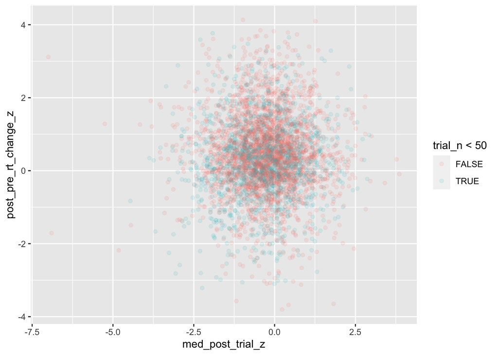

```r
# plot a ggplot2 point graph of trial_neural_behav_roi filtered by FailedStop, plotting med_post_trial_z against post_pre_rt_change_z
# coloring points by whether trial_n is <50 or not

ggplot(data = trial_neural_behav_roi %>%
          filter(condition=="FailedStop"),
        aes(x = med_post_trial_z,
            y = post_pre_rt_change_z,
            color = trial_n < 50)) +
   geom_point(alpha=0.1)
```

## trough

For comparison–if we use trough (it should generally be a trough for FS) do we still see the effect?

```r
model_P_stop_trial_w_change <- lme4::lmer(
   trough ~ trial_n_z + post_pre_rt_change_z + P_stop_trial_change_z +(1+ post_pre_rt_change_z + P_stop_trial_change_z  | subid),
  trial_neural_behav_roi %>% filter(trial_n>50 & condition %in% c("FailedStop"))
  )
summary(model_P_stop_trial_w_change)
```

```
## Linear mixed model fit by REML ['lmerMod']
## Formula: trough ~ trial_n_z + post_pre_rt_change_z + P_stop_trial_change_z +
##     (1 + post_pre_rt_change_z + P_stop_trial_change_z | subid)
##    Data: trial_neural_behav_roi %>% filter(trial_n > 50 & condition %in%
##     c("FailedStop"))
##
## REML criterion at convergence: 4906.4
##
## Scaled residuals:
##      Min       1Q   Median       3Q      Max
## -15.0886  -0.4064   0.0769   0.5448   3.3085
##
## Random effects:
##  Groups   Name                  Variance  Std.Dev. Corr
##  subid    (Intercept)           0.0104474 0.10221
##           post_pre_rt_change_z  0.0004304 0.02075  -0.25
##           P_stop_trial_change_z 0.0112166 0.10591  -0.90  0.65
##  Residual                       0.3073446 0.55439
## Number of obs: 2915, groups:  subid, 269
##
## Fixed effects:
##                        Estimate Std. Error t value
## (Intercept)           -0.853381   0.065756 -12.978
## trial_n_z              0.187808   0.031404   5.980
## post_pre_rt_change_z  -0.004164   0.009928  -0.419
## P_stop_trial_change_z  0.972248   0.180715   5.380
##
## Correlation of Fixed Effects:
##             (Intr) trl_n_ ps____
## trial_n_z   -0.919
## pst_pr_rt__ -0.079 -0.008
## P_stp_trl__ -0.980  0.910  0.010
```

```r
#ignoring post_pre_rt_change_z
model_P_stop_trial_w_change_no_rt <- lme4::lmer(
   trough ~ trial_n_z  + P_stop_trial_change_z +(1+ post_pre_rt_change_z + P_stop_trial_change_z  | subid),
  trial_neural_behav_roi %>% filter(trial_n>50 & condition %in% c("FailedStop"))
  )
```

```
## boundary (singular) fit: see help('isSingular')
```

```r
summary(model_P_stop_trial_w_change_no_rt)
```

```
## Linear mixed model fit by REML ['lmerMod']
## Formula:
## trough ~ trial_n_z + P_stop_trial_change_z + (1 + post_pre_rt_change_z +
##     P_stop_trial_change_z | subid)
##    Data: trial_neural_behav_roi %>% filter(trial_n > 50 & condition %in%
##     c("FailedStop"))
##
## REML criterion at convergence: 4899.3
##
## Scaled residuals:
##      Min       1Q   Median       3Q      Max
## -15.0917  -0.4052   0.0746   0.5460   3.3107
##
## Random effects:
##  Groups   Name                  Variance  Std.Dev.  Corr
##  subid    (Intercept)           9.400e-03 0.0969527
##           post_pre_rt_change_z  4.657e-07 0.0006824  1.00
##           P_stop_trial_change_z 5.471e-03 0.0739646 -1.00 -1.00
##  Residual                       3.078e-01 0.5547978
## Number of obs: 2915, groups:  subid, 269
##
## Fixed effects:
##                       Estimate Std. Error t value
## (Intercept)           -0.85588    0.06551 -13.065
## trial_n_z              0.18792    0.03139   5.986
## P_stop_trial_change_z  0.97353    0.18055   5.392
##
## Correlation of Fixed Effects:
##             (Intr) trl_n_
## trial_n_z   -0.923
## P_stp_trl__ -0.982  0.910
## optimizer (nloptwrap) convergence code: 0 (OK)
## boundary (singular) fit: see help('isSingular')
```

```r
anova(model_P_stop_trial_w_change,model_P_stop_trial_w_change_no_rt)
```

```
## refitting model(s) with ML (instead of REML)
```

```
## Data: trial_neural_behav_roi %>% filter(trial_n > 50 & condition %in%  ...
## Models:
## model_P_stop_trial_w_change_no_rt: trough ~ trial_n_z + P_stop_trial_change_z + (1 + post_pre_rt_change_z + P_stop_trial_change_z | subid)
## model_P_stop_trial_w_change: trough ~ trial_n_z + post_pre_rt_change_z + P_stop_trial_change_z + (1 + post_pre_rt_change_z + P_stop_trial_change_z | subid)
##                                   npar    AIC    BIC  logLik deviance  Chisq Df
## model_P_stop_trial_w_change_no_rt   10 4903.7 4963.4 -2441.8   4883.7
## model_P_stop_trial_w_change         11 4905.5 4971.2 -2441.7   4883.5 0.1762  1
##                                   Pr(>Chisq)
## model_P_stop_trial_w_change_no_rt
## model_P_stop_trial_w_change           0.6746
```

```r
#ignoring P_stop_trial_change_z
model_P_stop_trial_w_change_no_p_stop_d <- lme4::lmer(
   trough ~ trial_n_z +  post_pre_rt_change_z +(1+ post_pre_rt_change_z + P_stop_trial_change_z | subid),
  trial_neural_behav_roi %>% filter(trial_n>50 & condition %in% c("FailedStop"))
  )
```

```
## boundary (singular) fit: see help('isSingular')
```

```r
summary(model_P_stop_trial_w_change_no_p_stop_d)
```

```
## Linear mixed model fit by REML ['lmerMod']
## Formula:
## trough ~ trial_n_z + post_pre_rt_change_z + (1 + post_pre_rt_change_z +
##     P_stop_trial_change_z | subid)
##    Data: trial_neural_behav_roi %>% filter(trial_n > 50 & condition %in%
##     c("FailedStop"))
##
## REML criterion at convergence: 4933.6
##
## Scaled residuals:
##      Min       1Q   Median       3Q      Max
## -15.0737  -0.3990   0.0706   0.5442   3.4222
##
## Random effects:
##  Groups   Name                  Variance Std.Dev. Corr
##  subid    (Intercept)           0.011554 0.10749
##           post_pre_rt_change_z  0.000709 0.02663  -0.41
##           P_stop_trial_change_z 0.019925 0.14116  -0.83  0.85
##  Residual                       0.309823 0.55662
## Number of obs: 2915, groups:  subid, 269
##
## Fixed effects:
##                       Estimate Std. Error t value
## (Intercept)          -0.506794   0.013184 -38.439
## trial_n_z             0.034358   0.013155   2.612
## post_pre_rt_change_z -0.004787   0.010045  -0.477
##
## Correlation of Fixed Effects:
##             (Intr) trl_n_
## trial_n_z   -0.335
## pst_pr_rt__ -0.345 -0.049
## optimizer (nloptwrap) convergence code: 0 (OK)
## boundary (singular) fit: see help('isSingular')
```

```r
anova(model_P_stop_trial_w_change, model_P_stop_trial_w_change_no_p_stop_d)
```

```
## refitting model(s) with ML (instead of REML)
```

```
## Data: trial_neural_behav_roi %>% filter(trial_n > 50 & condition %in%  ...
## Models:
## model_P_stop_trial_w_change_no_p_stop_d: trough ~ trial_n_z + post_pre_rt_change_z + (1 + post_pre_rt_change_z + P_stop_trial_change_z | subid)
## model_P_stop_trial_w_change: trough ~ trial_n_z + post_pre_rt_change_z + P_stop_trial_change_z + (1 + post_pre_rt_change_z + P_stop_trial_change_z | subid)
##                                         npar    AIC    BIC  logLik deviance
## model_P_stop_trial_w_change_no_p_stop_d   10 4932.3 4992.1 -2456.2   4912.3
## model_P_stop_trial_w_change               11 4905.5 4971.2 -2441.7   4883.5
##                                          Chisq Df Pr(>Chisq)
## model_P_stop_trial_w_change_no_p_stop_d
## model_P_stop_trial_w_change             28.801  1   8.02e-08 ***
## ---
## Signif. codes:  0 '***' 0.001 '**' 0.01 '*' 0.05 '.' 0.1 ' ' 1
```

# Between-subjects measures

## Between subjects

```r
trial_neural_behav_data_not_na$trial_n_n<-scale(trial_neural_behav_data_not_na$trial_n_c)


FS_neural_behav_data_not_na<-trial_neural_behav_data_not_na[trial_neural_behav_data_not_na$condition=="FailedStop",]
```

```r
activity_by_subj <- trial_neural_behav_data_not_na %>% filter(condition %in% c("CorrectStop","FailedStop")) %>%
 group_by(subid,wave,runid,ROI_delateralized,condition) %>%
  summarize(mean_med_post_stop_signal=mean(med_post_trial),
            mean_post_pre_rt = mean(post_pre_rt_change),
            mean_peak = mean(peak),
            mean_trough = mean(trough)
            ) %>%
  tidyr::pivot_wider(names_from="condition", values_from=c("mean_med_post_stop_signal","mean_post_pre_rt", "mean_peak","mean_trough")) %>%
  mutate(
    "post_stop_signal_CSMinusFS"=mean_med_post_stop_signal_CorrectStop-mean_med_post_stop_signal_FailedStop,
    "post_pre_rt_CSMinusFS"=mean_post_pre_rt_CorrectStop-mean_post_pre_rt_FailedStop,
    "post_stop_signal_CSPeakMinusFSTrough" = mean_peak_CorrectStop-mean_trough_FailedStop
         )
```

```
## 'ROI_delateralized'. You can override using the `.groups` argument.
```

```r
# get subject-level FS>CS contrast for the relevant region
```

```r
behav_by_subj <- sst_all_data %>% group_by(subid, waveid, runid) %>%
  summarize(mean_ssrt_0=mean(mean_ssrt_0,na.rm=TRUE),
            stop_prop_correct = mean(stop_prop_correct,na.rm=TRUE)
            )
activity_by_subj_w1 <- activity_by_subj %>% filter(wave==1 & runid==1)

by_subj <- merge(behav_by_subj,activity_by_subj,
                 by.x=c("subid","waveid","runid"),by.y=c("subid","wave","runid"))
by_subj_striatum<-by_subj %>% filter(ROI_delateralized=="CueFollowing(CS>FS)striatal_cluster_combined")

by_subj_striatum_w1 <- by_subj_striatum%>% filter(waveid==1 & runid==1)

cor.test(by_subj_striatum_w1$mean_ssrt_0,by_subj_striatum_w1$post_stop_signal_CSMinusFS) # a
```

```
##
##  Pearson's product-moment correlation
##
## data:  by_subj_striatum_w1$mean_ssrt_0 and by_subj_striatum_w1$post_stop_signal_CSMinusFS
## t = -0.8259, df = 257, p-value = 0.4096
## alternative hypothesis: true correlation is not equal to 0
## 95 percent confidence interval:
##  -0.17225827  0.07088336
## sample estimates:
##         cor
## -0.05144984
```

```r
by_subj_striatum_no_outliers <- by_subj_striatum_w1 %>% filter(mean_ssrt_0>-0.2)

#does the size of the gap between signal for a subject indicate how much they're able to adjust in response to stimuli?
cor.test(by_subj_striatum_no_outliers$post_pre_rt_CSMinusFS,by_subj_striatum_no_outliers$post_stop_signal_CSMinusFS)
```

```
##
##  Pearson's product-moment correlation
##
## data:  by_subj_striatum_no_outliers$post_pre_rt_CSMinusFS and by_subj_striatum_no_outliers$post_stop_signal_CSMinusFS
## t = 1.654, df = 257, p-value = 0.09934
## alternative hypothesis: true correlation is not equal to 0
## 95 percent confidence interval:
##  -0.0195011  0.2217463
## sample estimates:
##       cor
## 0.1026315
```

```r
#no.

#but does the size of that gap indicate their SSRT?
cor.test(by_subj_striatum_no_outliers$mean_ssrt_0,by_subj_striatum_no_outliers$post_stop_signal_CSMinusFS) # a good start
```

```
##
##  Pearson's product-moment correlation
##
## data:  by_subj_striatum_no_outliers$mean_ssrt_0 and by_subj_striatum_no_outliers$post_stop_signal_CSMinusFS
## t = -0.8259, df = 257, p-value = 0.4096
## alternative hypothesis: true correlation is not equal to 0
## 95 percent confidence interval:
##  -0.17225827  0.07088336
## sample estimates:
##         cor
## -0.05144984
```

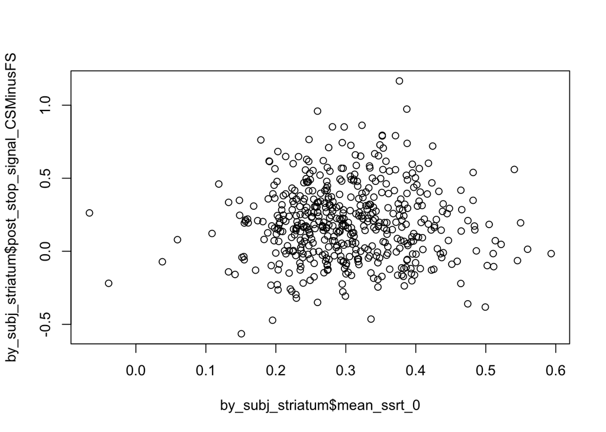

```r
#no, not remotely, once we remove the subjects who don't seem to be paying attention

plot(by_subj_striatum$mean_ssrt_0,by_subj_striatum$post_stop_signal_CSMinusFS)
plot(by_subj_striatum$mean_ssrt_0,by_subj_striatum$post_stop_signal_CSMinusFS)
```

```r
by_subj_striatum_no_outliers <- by_subj_striatum_w1 %>% filter(mean_ssrt_0>-0.2 & stop_prop_correct>=0.4 & stop_prop_correct<=0.6)

#does the size of the gap between signal for a subject indicate how much they're able to adjust in response to stimuli?
cor.test(by_subj_striatum_no_outliers$post_pre_rt_CSMinusFS,by_subj_striatum_no_outliers$post_stop_signal_CSMinusFS)
```

```
##
##  Pearson's product-moment correlation
##
## data:  by_subj_striatum_no_outliers$post_pre_rt_CSMinusFS and by_subj_striatum_no_outliers$post_stop_signal_CSMinusFS
## t = 2.238, df = 176, p-value = 0.02648
## alternative hypothesis: true correlation is not equal to 0
## 95 percent confidence interval:
##  0.0197407 0.3059418
## sample estimates:
##       cor
## 0.1663424
```

```r
#SUBJECTS who had stronger signals had stronger RT adjustments. This is useful. Sort of.

#but does the size of that gap indicate their SSRT?
cor.test(by_subj_striatum_no_outliers$mean_ssrt_0,by_subj_striatum_no_outliers$post_stop_signal_CSMinusFS) # a good start
```

```
##
##  Pearson's product-moment correlation
##
## data:  by_subj_striatum_no_outliers$mean_ssrt_0 and by_subj_striatum_no_outliers$post_stop_signal_CSMinusFS
## t = -0.017875, df = 176, p-value = 0.9858
## alternative hypothesis: true correlation is not equal to 0
## 95 percent confidence interval:
##  -0.1484027  0.1457662
## sample estimates:
##          cor
## -0.001347385
```

```r
#no
```